# Исследование объявлений о продаже квартир

В вашем распоряжении данные сервиса Яндекс.Недвижимость — архив объявлений о продаже квартир в Санкт-Петербурге и соседних населённых пунктах за несколько лет. Нужно научиться определять рыночную стоимость объектов недвижимости. Ваша задача — установить параметры. Это позволит построить автоматизированную систему: она отследит аномалии и мошенническую деятельность.

По каждой квартире на продажу доступны два вида данных. Первые вписаны пользователем, вторые получены автоматически на основе картографических данных. Например, расстояние до центра, аэропорта, ближайшего парка и водоёма.

## Изучение данных из файла

```python
import pandas as pd
import numpy as np

pd.set_option('display.float_format', '{:,.2f}'.format)
```

```python
df = pd.read_csv('/datasets/real_estate_data.csv', sep='\t')
df.info()
df.columns
```

```
<class 'pandas.core.frame.DataFrame'>
RangeIndex: 23699 entries, 0 to 23698
Data columns (total 22 columns):
 #   Column                Non-Null Count  Dtype
---  ------                --------------  -----
 0   total_images          23699 non-null  int64
 1   last_price            23699 non-null  float64
 2   total_area            23699 non-null  float64
 3   first_day_exposition  23699 non-null  object
 4   rooms                 23699 non-null  int64
 5   ceiling_height        14504 non-null  float64
 6   floors_total          23613 non-null  float64
 7   living_area           21796 non-null  float64
 8   floor                 23699 non-null  int64
 9   is_apartment          2775 non-null   object
 10  studio                23699 non-null  bool
 11  open_plan             23699 non-null  bool
 12  kitchen_area          21421 non-null  float64
 13  balcony               12180 non-null  float64
 14  locality_name         23650 non-null  object
 15  airports_nearest      18157 non-null  float64
 16  cityCenters_nearest   18180 non-null  float64
 17  parks_around3000      18181 non-null  float64
 18  parks_nearest         8079 non-null   float64
 19  ponds_around3000      18181 non-null  float64
 20  ponds_nearest         9110 non-null   float64
 21  days_exposition       20518 non-null  float64
dtypes: bool(2), float64(14), int64(3), object(3)
memory usage: 3.7+ MB
```

```
Index(['total_images', 'last_price', 'total_area', 'first_day_exposition',
       'rooms', 'ceiling_height', 'floors_total', 'living_area', 'floor',
       'is_apartment', 'studio', 'open_plan', 'kitchen_area', 'balcony',
       'locality_name', 'airports_nearest', 'cityCenters_nearest',
       'parks_around3000', 'parks_nearest', 'ponds_around3000',
       'ponds_nearest', 'days_exposition'],
      dtype='object')
```

```python
display(df.head())
```

|  | total_images | last_price | total_area | first_day_exposition | rooms | ceiling_height | floors_total | living_area | floor | is_apartment | ... | kitchen_area | balcony | locality_name | airports_nearest | cityCenters_nearest | parks_around3000 | parks_nearest | ponds_around3000 | ponds_nearest | days_exposition |
| --- | --- | --- | --- | --- | --- | --- | --- | --- | --- | --- | --- | --- | --- | --- | --- | --- | --- | --- | --- | --- | --- |
| 0 | 20 | 13,000,000.00 | 108.00 | 2019-03-07T00:00:00 | 3 | 2.70 | 16.00 | 51.00 | 8 | NaN | ... | 25.00 | NaN | Санкт-Петербург | 18,863.00 | 16,028.00 | 1.00 | 482.00 | 2.00 | 755.00 | NaN |
| 1 | 7 | 3,350,000.00 | 40.40 | 2018-12-04T00:00:00 | 1 | NaN | 11.00 | 18.60 | 1 | NaN | ... | 11.00 | 2.00 | посёлок Шушары | 12,817.00 | 18,603.00 | 0.00 | NaN | 0.00 | NaN | 81.00 |
| 2 | 10 | 5,196,000.00 | 56.00 | 2015-08-20T00:00:00 | 2 | NaN | 5.00 | 34.30 | 4 | NaN | ... | 8.30 | 0.00 | Санкт-Петербург | 21,741.00 | 13,933.00 | 1.00 | 90.00 | 2.00 | 574.00 | 558.00 |
| 3 | 0 | 64,900,000.00 | 159.00 | 2015-07-24T00:00:00 | 3 | NaN | 14.00 | NaN | 9 | NaN | ... | NaN | 0.00 | Санкт-Петербург | 28,098.00 | 6,800.00 | 2.00 | 84.00 | 3.00 | 234.00 | 424.00 |
| 4 | 2 | 10,000,000.00 | 100.00 | 2018-06-19T00:00:00 | 2 | 3.03 | 14.00 | 32.00 | 13 | NaN | ... | 41.00 | NaN | Санкт-Петербург | 31,856.00 | 8,098.00 | 2.00 | 112.00 | 1.00 | 48.00 | 121.00 |

5 rows × 22 columns

### Вывод

При чтении таблицы столкнулся с тем, что строки слепились, т.е. они разделены не запятыми, а `\t`, поэтому при чтении csv-файла использовал параметр `sep='\t'`. Имена колонок без лишних пробелов и введины согласно правилам написания, однако во многих столбцах много пропусков. Необходимо, по-возможности их убрать.

## Предобработка данных

```python
# подсчёт пропущенных значений
df.isna().sum()
```

```
total_images                0
last_price                  0
total_area                  0
first_day_exposition        0
rooms                       0
ceiling_height           9195
floors_total               86
living_area              1903
floor                       0
is_apartment            20924
studio                      0
open_plan                   0
kitchen_area             2278
balcony                 11519
locality_name              49
airports_nearest         5542
cityCenters_nearest      5519
parks_around3000         5518
parks_nearest           15620
ponds_around3000         5518
ponds_nearest           14589
days_exposition          3181
dtype: int64
```

```python
# оценка доли пропусков
df.isna().mean().apply('{:.0%}'.format)
```

```
total_images             0%
last_price               0%
total_area               0%
first_day_exposition     0%
rooms                    0%
ceiling_height          39%
floors_total             0%
living_area              8%
floor                    0%
is_apartment            88%
studio                   0%
open_plan                0%
kitchen_area            10%
balcony                 49%
locality_name            0%
airports_nearest        23%
cityCenters_nearest     23%
parks_around3000        23%
parks_nearest           66%
ponds_around3000        23%
ponds_nearest           62%
days_exposition         13%
dtype: object
```

```python
#проверим значения в столбцах для поиска аномалий
df['last_price'].describe()
```

```
count        23,699.00
mean      6,541,548.77
std      10,887,013.27
min          12,190.00
25%       3,400,000.00
50%       4,650,000.00
75%       6,800,000.00
max     763,000,000.00
Name: last_price, dtype: float64
```

```python
# проверю, что за квартира с минимальной ценой
df.loc[df['last_price'] == df['last_price'].min()]
```

|  | total_images | last_price | total_area | first_day_exposition | rooms | ceiling_height | floors_total | living_area | floor | is_apartment | ... | kitchen_area | balcony | locality_name | airports_nearest | cityCenters_nearest | parks_around3000 | parks_nearest | ponds_around3000 | ponds_nearest | days_exposition |
| --- | --- | --- | --- | --- | --- | --- | --- | --- | --- | --- | --- | --- | --- | --- | --- | --- | --- | --- | --- | --- | --- |
| 8793 | 7 | 12,190.00 | 109.00 | 2019-03-20T00:00:00 | 2 | 2.75 | 25.00 | 32.00 | 25 | NaN | ... | 40.50 | NaN | Санкт-Петербург | 36,421.00 | 9,176.00 | 1.00 | 805.00 | 0.00 | NaN | 8.00 |

1 rows × 22 columns

```python
# проверю, есть ли ещё квартиры проданные менее чем за 100 тыс рублей
df.loc[df['last_price'] < 100000]
```

|  | total_images | last_price | total_area | first_day_exposition | rooms | ceiling_height | floors_total | living_area | floor | is_apartment | ... | kitchen_area | balcony | locality_name | airports_nearest | cityCenters_nearest | parks_around3000 | parks_nearest | ponds_around3000 | ponds_nearest | days_exposition |
| --- | --- | --- | --- | --- | --- | --- | --- | --- | --- | --- | --- | --- | --- | --- | --- | --- | --- | --- | --- | --- | --- |
| 8793 | 7 | 12,190.00 | 109.00 | 2019-03-20T00:00:00 | 2 | 2.75 | 25.00 | 32.00 | 25 | NaN | ... | 40.50 | NaN | Санкт-Петербург | 36,421.00 | 9,176.00 | 1.00 | 805.00 | 0.00 | NaN | 8.00 |

1 rows × 22 columns

Вряд ли квартира с площадью 109 квадратных метров продавалась за 12 тыс рублей. Скорее всего даные укзали в тысю рублях по ошибке. Учитывая, что такая квартира всег одна, то заменю 12190 руб на 12190000 руб.

```python
# меняю тыс. руб на просто руб по анологии с остаьными данными
df['last_price'] =df['last_price'].replace(12190, 12190000)
```

```python
# в столбце "last_price" только целые значения, для удбства приведём их к целочисленному типу данных
df['last_price'] = df['last_price'].astype(int)
df['last_price'].sample()
```

```
17736    12980000
Name: last_price, dtype: int64
```

```python
df['total_area'].describe()
```

```
count   23,699.00
mean        60.35
std         35.65
min         12.00
25%         40.00
50%         52.00
75%         69.90
max        900.00
Name: total_area, dtype: float64
```

```python
df['first_day_exposition'].describe()
```

```
count                   23699
unique                   1491
top       2018-02-01T00:00:00
freq                      368
Name: first_day_exposition, dtype: object
```

```python
# приведём формат коолонки к дате без времени, так как время не указано
df['first_day_exposition'] = pd.to_datetime(df['first_day_exposition'], format='%Y-%m-%d')
df['first_day_exposition'].sample()
```

```
15101   2016-01-27
Name: first_day_exposition, dtype: datetime64[ns]
```

```python
df['rooms'].describe()
```

```
count   23,699.00
mean         2.07
std          1.08
min          0.00
25%          1.00
50%          2.00
75%          3.00
max         19.00
Name: rooms, dtype: float64
```

```python
# проверяю, что за обьявления с нулём комнат. возможно это студии
df[(df['rooms'] == 0) & (df['studio'] == 1)]
```

|  | total_images | last_price | total_area | first_day_exposition | rooms | ceiling_height | floors_total | living_area | floor | is_apartment | ... | kitchen_area | balcony | locality_name | airports_nearest | cityCenters_nearest | parks_around3000 | parks_nearest | ponds_around3000 | ponds_nearest | days_exposition |
| --- | --- | --- | --- | --- | --- | --- | --- | --- | --- | --- | --- | --- | --- | --- | --- | --- | --- | --- | --- | --- | --- |
| 144 | 1 | 2450000 | 27.00 | 2017-03-30 | 0 | NaN | 24.00 | 15.50 | 2 | NaN | ... | NaN | 2.00 | посёлок Мурино | NaN | NaN | NaN | NaN | NaN | NaN | 181.00 |
| 440 | 8 | 2480000 | 27.11 | 2018-03-12 | 0 | NaN | 17.00 | 24.75 | 4 | NaN | ... | NaN | 2.00 | Санкт-Петербург | 38,171.00 | 15,015.00 | 0.00 | NaN | 2.00 | 982.00 | 64.00 |
| 608 | 2 | 1850000 | 25.00 | 2019-02-20 | 0 | NaN | 10.00 | NaN | 7 | NaN | ... | NaN | NaN | посёлок Шушары | NaN | NaN | NaN | NaN | NaN | NaN | 29.00 |
| 697 | 12 | 2500000 | 24.10 | 2017-12-01 | 0 | 2.75 | 25.00 | 17.50 | 21 | NaN | ... | NaN | NaN | деревня Кудрово | NaN | NaN | NaN | NaN | NaN | NaN | 201.00 |
| 716 | 5 | 1500000 | 17.00 | 2017-06-07 | 0 | 2.70 | 9.00 | 12.00 | 1 | NaN | ... | NaN | 0.00 | посёлок Шушары | 18,654.00 | 29,846.00 | 0.00 | NaN | 0.00 | NaN | 40.00 |
| ... | ... | ... | ... | ... | ... | ... | ... | ... | ... | ... | ... | ... | ... | ... | ... | ... | ... | ... | ... | ... | ... |
| 22867 | 8 | 3090000 | 30.00 | 2017-12-17 | 0 | NaN | 25.00 | 18.20 | 5 | NaN | ... | NaN | NaN | Санкт-Петербург | 35,250.00 | 16,414.00 | 0.00 | NaN | 1.00 | 400.00 | 211.00 |
| 22877 | 2 | 4280000 | 28.00 | 2017-10-26 | 0 | 2.70 | 19.00 | 18.00 | 10 | NaN | ... | NaN | NaN | Санкт-Петербург | 18,982.00 | 7,206.00 | 0.00 | NaN | 1.00 | 415.00 | 151.00 |
| 23210 | 7 | 3200000 | 26.00 | 2017-09-01 | 0 | NaN | 25.00 | 18.00 | 16 | NaN | ... | NaN | 0.00 | Санкт-Петербург | 11,405.00 | 13,222.00 | 0.00 | NaN | 1.00 | 623.00 | 14.00 |
| 23554 | 15 | 3350000 | 26.00 | 2018-09-07 | 0 | NaN | 19.00 | NaN | 8 | NaN | ... | NaN | NaN | Санкт-Петербург | 18,090.00 | 17,092.00 | 0.00 | NaN | 2.00 | 112.00 | 31.00 |
| 23637 | 8 | 2350000 | 26.00 | 2018-06-26 | 0 | NaN | 25.00 | 17.00 | 4 | NaN | ... | NaN | 2.00 | посёлок Бугры | NaN | NaN | NaN | NaN | NaN | NaN | 207.00 |

138 rows × 22 columns

```python
df[(df['rooms'] == 0) & (df['studio'] == 0)]
```

|  | total_images | last_price | total_area | first_day_exposition | rooms | ceiling_height | floors_total | living_area | floor | is_apartment | ... | kitchen_area | balcony | locality_name | airports_nearest | cityCenters_nearest | parks_around3000 | parks_nearest | ponds_around3000 | ponds_nearest | days_exposition |
| --- | --- | --- | --- | --- | --- | --- | --- | --- | --- | --- | --- | --- | --- | --- | --- | --- | --- | --- | --- | --- | --- |
| 349 | 4 | 2320000 | 25.00 | 2017-09-27 | 0 | NaN | 14.00 | 17.00 | 1 | NaN | ... | NaN | 0.00 | деревня Кудрово | NaN | NaN | NaN | NaN | NaN | NaN | 45.00 |
| 508 | 0 | 3375000 | 34.40 | 2017-03-28 | 0 | NaN | 26.00 | 24.30 | 19 | NaN | ... | NaN | 1.00 | посёлок Парголово | 53,115.00 | 19,292.00 | 0.00 | NaN | 1.00 | 593.00 | 430.00 |
| 780 | 9 | 2600000 | 26.10 | 2018-02-20 | 0 | NaN | 18.00 | NaN | 8 | NaN | ... | NaN | 1.00 | посёлок Мурино | NaN | NaN | NaN | NaN | NaN | NaN | 45.00 |
| 839 | 14 | 1900000 | 35.00 | 2017-04-14 | 0 | 2.70 | 5.00 | 15.00 | 3 | False | ... | NaN | 1.00 | поселок Новый Свет | NaN | NaN | NaN | NaN | NaN | NaN | 7.00 |
| 946 | 5 | 2200000 | 23.00 | 2016-09-27 | 0 | NaN | 27.00 | 18.00 | 7 | NaN | ... | NaN | 2.00 | посёлок Мурино | NaN | NaN | NaN | NaN | NaN | NaN | 483.00 |
| 1574 | 0 | 2200000 | 22.00 | 2017-11-03 | 0 | NaN | 18.00 | 15.00 | 16 | NaN | ... | NaN | 1.00 | деревня Кудрово | NaN | NaN | NaN | NaN | NaN | NaN | 81.00 |
| 1625 | 7 | 1980000 | 23.98 | 2018-02-01 | 0 | NaN | 4.00 | 10.50 | 3 | NaN | ... | NaN | 1.00 | поселок станции Корнево | NaN | NaN | NaN | NaN | NaN | NaN | 120.00 |
| 2532 | 5 | 3500000 | 27.10 | 2018-02-01 | 0 | NaN | 18.00 | 18.70 | 9 | NaN | ... | NaN | 2.00 | Санкт-Петербург | 32,036.00 | 8,175.00 | 0.00 | NaN | 1.00 | 644.00 | 70.00 |
| 3019 | 18 | 2100000 | 24.00 | 2017-11-10 | 0 | NaN | 10.00 | 18.00 | 6 | NaN | ... | NaN | 2.00 | Сертолово | NaN | NaN | NaN | NaN | NaN | NaN | 5.00 |
| 4115 | 7 | 2600000 | 24.00 | 2018-02-01 | 0 | NaN | 25.00 | 18.00 | 4 | NaN | ... | NaN | 2.00 | Санкт-Петербург | 10,031.00 | 13,330.00 | 1.00 | 915.00 | 0.00 | NaN | 42.00 |
| 4437 | 10 | 3200000 | 25.00 | 2017-10-16 | 0 | NaN | 9.00 | 18.60 | 9 | NaN | ... | NaN | 2.00 | Санкт-Петербург | 11,943.00 | 11,710.00 | 1.00 | 518.00 | 1.00 | 232.00 | 97.00 |
| 4683 | 2 | 3650000 | 35.00 | 2018-02-01 | 0 | NaN | 25.00 | 23.40 | 25 | NaN | ... | NaN | NaN | Санкт-Петербург | 43,431.00 | 12,188.00 | 0.00 | NaN | 0.00 | NaN | 100.00 |
| 4876 | 7 | 3000000 | 25.00 | 2017-09-27 | 0 | 27.00 | 25.00 | 17.00 | 17 | NaN | ... | NaN | 2.00 | посёлок Мурино | NaN | NaN | NaN | NaN | NaN | NaN | 28.00 |
| 5749 | 20 | 3590000 | 25.00 | 2017-08-30 | 0 | 2.80 | 35.00 | NaN | 26 | NaN | ... | NaN | 2.00 | Санкт-Петербург | 18,732.00 | 20,444.00 | 0.00 | NaN | 3.00 | 80.00 | 198.00 |
| 6472 | 13 | 3620000 | 28.00 | 2017-11-10 | 0 | 2.70 | 20.00 | 18.00 | 17 | NaN | ... | NaN | 2.00 | Санкт-Петербург | 35,068.00 | 16,167.00 | 0.00 | NaN | 0.00 | NaN | 37.00 |
| 6612 | 18 | 3590000 | 26.80 | 2017-11-10 | 0 | NaN | 24.00 | 19.00 | 20 | NaN | ... | NaN | NaN | Санкт-Петербург | 11,022.00 | 12,679.00 | 0.00 | NaN | 0.00 | NaN | 15.00 |
| 6805 | 7 | 1850000 | 31.00 | 2017-11-10 | 0 | NaN | 18.00 | 18.00 | 10 | NaN | ... | NaN | 1.00 | Никольское | NaN | NaN | NaN | NaN | NaN | NaN | 7.00 |
| 7008 | 4 | 5200000 | 32.30 | 2017-09-14 | 0 | NaN | 11.00 | 25.50 | 4 | NaN | ... | NaN | NaN | Санкт-Петербург | 30,824.00 | 6,469.00 | 1.00 | 756.00 | 1.00 | 936.00 | 86.00 |
| 7237 | 8 | 2999000 | 42.63 | 2017-11-27 | 0 | NaN | 16.00 | 25.70 | 2 | NaN | ... | NaN | 2.00 | деревня Кудрово | NaN | NaN | NaN | NaN | NaN | NaN | 45.00 |
| 7286 | 6 | 2580000 | 30.00 | 2018-02-07 | 0 | NaN | 18.00 | 19.00 | 2 | NaN | ... | NaN | NaN | посёлок Парголово | 52,610.00 | 18,787.00 | 0.00 | NaN | 0.00 | NaN | 41.00 |
| 7818 | 11 | 3300000 | 27.30 | 2018-04-06 | 0 | NaN | 20.00 | NaN | 9 | NaN | ... | NaN | 2.00 | Санкт-Петербург | 15,990.00 | 13,853.00 | 0.00 | NaN | 1.00 | 584.00 | 31.00 |
| 9412 | 5 | 2100000 | 16.00 | 2017-12-10 | 0 | NaN | 6.00 | 13.00 | 1 | NaN | ... | NaN | NaN | Санкт-Петербург | 20,735.00 | 2,111.00 | 2.00 | 228.00 | 3.00 | 72.00 | 3.00 |
| 9586 | 7 | 1670000 | 28.30 | 2017-09-27 | 0 | NaN | 9.00 | 18.20 | 3 | NaN | ... | NaN | 0.00 | Никольское | NaN | NaN | NaN | NaN | NaN | NaN | 45.00 |
| 9861 | 10 | 2350000 | 25.00 | 2017-12-03 | 0 | NaN | 22.00 | 25.00 | 17 | NaN | ... | NaN | 2.00 | посёлок Мурино | NaN | NaN | NaN | NaN | NaN | NaN | 13.00 |
| 10284 | 9 | 2700000 | 24.00 | 2017-01-23 | 0 | NaN | 12.00 | 15.50 | 11 | NaN | ... | NaN | 1.00 | деревня Кудрово | NaN | NaN | NaN | NaN | NaN | NaN | 357.00 |
| 10606 | 14 | 2950000 | 25.27 | 2017-11-17 | 0 | NaN | 25.00 | 25.00 | 11 | NaN | ... | NaN | 1.00 | Санкт-Петербург | 11,405.00 | 13,222.00 | 0.00 | NaN | 1.00 | 623.00 | 51.00 |
| 11035 | 1 | 2500000 | 26.00 | 2017-11-10 | 0 | NaN | 8.00 | 14.00 | 6 | NaN | ... | NaN | NaN | городской посёлок Янино-1 | NaN | NaN | NaN | NaN | NaN | NaN | 22.00 |
| 11051 | 2 | 2200000 | 26.00 | 2017-10-24 | 0 | NaN | 21.00 | 12.00 | 21 | NaN | ... | NaN | 2.00 | деревня Кудрово | NaN | NaN | NaN | NaN | NaN | NaN | 35.00 |
| 11157 | 0 | 2900000 | 27.30 | 2017-11-22 | 0 | 2.80 | 8.00 | 20.00 | 5 | NaN | ... | NaN | NaN | Санкт-Петербург | 38,832.00 | 13,729.00 | 0.00 | NaN | 0.00 | NaN | 9.00 |
| 11331 | 6 | 1315000 | 27.32 | 2017-09-29 | 0 | 2.70 | 15.00 | 18.70 | 15 | NaN | ... | NaN | NaN | Никольское | NaN | NaN | NaN | NaN | NaN | NaN | 116.00 |
| 11692 | 0 | 2550000 | 23.06 | 2017-10-24 | 0 | 2.80 | 14.00 | 18.00 | 9 | NaN | ... | NaN | 2.00 | деревня Кудрово | NaN | NaN | NaN | NaN | NaN | NaN | 20.00 |
| 11705 | 5 | 3380000 | 26.00 | 2018-02-20 | 0 | 2.80 | 17.00 | 17.00 | 8 | NaN | ... | NaN | 1.00 | Санкт-Петербург | 15,706.00 | 7,734.00 | 2.00 | 592.00 | 1.00 | 802.00 | 45.00 |
| 12412 | 0 | 3300000 | 27.00 | 2017-08-15 | 0 | NaN | 25.00 | 25.00 | 22 | NaN | ... | NaN | NaN | Санкт-Петербург | 12,199.00 | 12,111.00 | 0.00 | NaN | 1.00 | 337.00 | 161.00 |
| 12691 | 1 | 3700000 | 24.20 | 2017-11-10 | 0 | NaN | 19.00 | 24.20 | 13 | NaN | ... | NaN | 1.00 | Санкт-Петербург | 17,837.00 | 16,840.00 | 0.00 | NaN | 2.00 | 210.00 | 74.00 |
| 13953 | 21 | 3255000 | 28.20 | 2017-09-26 | 0 | NaN | 24.00 | 20.00 | 2 | NaN | ... | NaN | NaN | Санкт-Петербург | 41,466.00 | 11,538.00 | 0.00 | NaN | 0.00 | NaN | 119.00 |
| 15105 | 8 | 2500000 | 26.10 | 2017-12-01 | 0 | NaN | 25.00 | 18.00 | 4 | NaN | ... | NaN | 2.00 | посёлок Мурино | NaN | NaN | NaN | NaN | NaN | NaN | 45.00 |
| 15273 | 9 | 2700000 | 25.20 | 2017-11-10 | 0 | NaN | 9.00 | 15.20 | 2 | NaN | ... | NaN | 2.00 | деревня Кудрово | NaN | NaN | NaN | NaN | NaN | NaN | 23.00 |
| 15434 | 0 | 2200000 | 27.00 | 2017-01-01 | 0 | NaN | 25.00 | 15.00 | 5 | NaN | ... | NaN | 2.00 | посёлок Парголово | 53,791.00 | 18,006.00 | 1.00 | 733.00 | 3.00 | 865.00 | 336.00 |
| 16429 | 2 | 2460000 | 28.01 | 2017-08-17 | 0 | NaN | 17.00 | 18.10 | 5 | NaN | ... | NaN | 1.00 | деревня Кудрово | NaN | NaN | NaN | NaN | NaN | NaN | 15.00 |
| 17695 | 7 | 2550000 | 24.00 | 2017-12-16 | 0 | NaN | 23.00 | 17.00 | 8 | NaN | ... | NaN | 1.00 | деревня Кудрово | NaN | NaN | NaN | NaN | NaN | NaN | 38.00 |
| 17729 | 7 | 2948000 | 28.05 | 2017-12-09 | 0 | NaN | 14.00 | 21.80 | 9 | NaN | ... | NaN | 2.00 | Санкт-Петербург | 22,098.00 | 23,810.00 | 0.00 | NaN | 2.00 | 100.00 | 45.00 |
| 17805 | 17 | 2600000 | 31.10 | 2017-10-25 | 0 | NaN | 16.00 | 21.40 | 14 | NaN | ... | NaN | 2.00 | Санкт-Петербург | 19,212.00 | 22,637.00 | 0.00 | NaN | 1.00 | 457.00 | 44.00 |
| 17824 | 10 | 2300000 | 22.50 | 2017-09-27 | 0 | NaN | 22.00 | 20.00 | 7 | NaN | ... | NaN | 2.00 | посёлок Мурино | NaN | NaN | NaN | NaN | NaN | NaN | 11.00 |
| 18042 | 15 | 2950000 | 25.90 | 2017-12-09 | 0 | NaN | 14.00 | 16.90 | 9 | NaN | ... | NaN | 2.00 | Санкт-Петербург | 23,239.00 | 12,102.00 | 1.00 | 1,021.00 | 1.00 | 893.00 | 45.00 |
| 18549 | 16 | 3699000 | 29.00 | 2017-11-11 | 0 | NaN | 16.00 | 19.00 | 11 | NaN | ... | NaN | 2.00 | Санкт-Петербург | 10,949.00 | 12,890.00 | 0.00 | NaN | 0.00 | NaN | 70.00 |
| 18782 | 0 | 2500000 | 25.00 | 2017-10-08 | 0 | NaN | 22.00 | 17.00 | 19 | NaN | ... | NaN | 1.00 | деревня Кудрово | NaN | NaN | NaN | NaN | NaN | NaN | 8.00 |
| 19392 | 5 | 71000000 | 371.00 | 2018-07-26 | 0 | 3.57 | 7.00 | NaN | 6 | NaN | ... | NaN | NaN | Санкт-Петербург | 25,257.00 | 6,060.00 | 1.00 | 761.00 | 1.00 | 584.00 | 90.00 |
| 19477 | 11 | 2300000 | 20.00 | 2017-11-10 | 0 | NaN | 10.00 | 16.00 | 1 | NaN | ... | NaN | NaN | Санкт-Петербург | 29,791.00 | 12,652.00 | 0.00 | NaN | 1.00 | 815.00 | 35.00 |
| 19735 | 1 | 2800000 | 30.50 | 2017-10-10 | 0 | 2.75 | 25.00 | 20.00 | 2 | NaN | ... | NaN | 2.00 | деревня Кудрово | NaN | NaN | NaN | NaN | NaN | NaN | 13.00 |
| 19917 | 5 | 2340000 | 25.41 | 2017-09-29 | 0 | NaN | 25.00 | 18.50 | 13 | NaN | ... | NaN | 0.00 | деревня Кудрово | NaN | NaN | NaN | NaN | NaN | NaN | 3.00 |
| 20002 | 8 | 2700000 | 28.00 | 2017-11-10 | 0 | NaN | 21.00 | 20.00 | 6 | NaN | ... | NaN | 2.00 | Санкт-Петербург | 21,460.00 | 16,788.00 | 0.00 | NaN | 1.00 | 170.00 | 17.00 |
| 20045 | 3 | 3100000 | 25.00 | 2017-09-27 | 0 | NaN | 24.00 | 18.00 | 24 | NaN | ... | NaN | 2.00 | Санкт-Петербург | 33,416.00 | 14,557.00 | 0.00 | NaN | 0.00 | NaN | 7.00 |
| 20054 | 5 | 2730000 | 21.00 | 2017-11-22 | 0 | NaN | 9.00 | 14.00 | 6 | NaN | ... | NaN | NaN | Санкт-Петербург | 17,048.00 | 5,936.00 | 2.00 | 462.00 | 0.00 | NaN | 45.00 |
| 20793 | 13 | 3600000 | 27.50 | 2017-11-10 | 0 | NaN | 24.00 | 19.00 | 23 | NaN | ... | NaN | 2.00 | Санкт-Петербург | 11,555.00 | 12,099.00 | 0.00 | NaN | 1.00 | 527.00 | 74.00 |
| 21299 | 13 | 2450000 | 28.50 | 2017-11-22 | 0 | NaN | 12.00 | 18.00 | 7 | NaN | ... | NaN | 2.00 | Санкт-Петербург | 20,381.00 | 19,383.00 | 0.00 | NaN | 1.00 | 579.00 | 73.00 |
| 21628 | 9 | 3900000 | 34.00 | 2017-03-18 | 0 | NaN | 20.00 | 24.00 | 10 | NaN | ... | NaN | 2.00 | Санкт-Петербург | 15,506.00 | 13,615.00 | 0.00 | NaN | 1.00 | 767.00 | 320.00 |
| 22573 | 8 | 2250000 | 24.00 | 2017-09-28 | 0 | NaN | 12.00 | 15.00 | 3 | NaN | ... | NaN | 2.00 | городской посёлок Новоселье | NaN | NaN | NaN | NaN | NaN | NaN | 45.00 |
| 23442 | 0 | 2500000 | 27.70 | 2017-09-28 | 0 | NaN | 24.00 | 18.00 | 4 | NaN | ... | NaN | 2.00 | посёлок Мурино | NaN | NaN | NaN | NaN | NaN | NaN | 4.00 |
| 23592 | 10 | 1450000 | 29.00 | 2017-11-11 | 0 | NaN | 9.00 | 18.00 | 8 | NaN | ... | NaN | 2.00 | Никольское | NaN | NaN | NaN | NaN | NaN | NaN | 82.00 |

59 rows × 22 columns

```python
df[(df['rooms'] == 0)]
```

|  | total_images | last_price | total_area | first_day_exposition | rooms | ceiling_height | floors_total | living_area | floor | is_apartment | ... | kitchen_area | balcony | locality_name | airports_nearest | cityCenters_nearest | parks_around3000 | parks_nearest | ponds_around3000 | ponds_nearest | days_exposition |
| --- | --- | --- | --- | --- | --- | --- | --- | --- | --- | --- | --- | --- | --- | --- | --- | --- | --- | --- | --- | --- | --- |
| 144 | 1 | 2450000 | 27.00 | 2017-03-30 | 0 | NaN | 24.00 | 15.50 | 2 | NaN | ... | NaN | 2.00 | посёлок Мурино | NaN | NaN | NaN | NaN | NaN | NaN | 181.00 |
| 349 | 4 | 2320000 | 25.00 | 2017-09-27 | 0 | NaN | 14.00 | 17.00 | 1 | NaN | ... | NaN | 0.00 | деревня Кудрово | NaN | NaN | NaN | NaN | NaN | NaN | 45.00 |
| 440 | 8 | 2480000 | 27.11 | 2018-03-12 | 0 | NaN | 17.00 | 24.75 | 4 | NaN | ... | NaN | 2.00 | Санкт-Петербург | 38,171.00 | 15,015.00 | 0.00 | NaN | 2.00 | 982.00 | 64.00 |
| 508 | 0 | 3375000 | 34.40 | 2017-03-28 | 0 | NaN | 26.00 | 24.30 | 19 | NaN | ... | NaN | 1.00 | посёлок Парголово | 53,115.00 | 19,292.00 | 0.00 | NaN | 1.00 | 593.00 | 430.00 |
| 608 | 2 | 1850000 | 25.00 | 2019-02-20 | 0 | NaN | 10.00 | NaN | 7 | NaN | ... | NaN | NaN | посёлок Шушары | NaN | NaN | NaN | NaN | NaN | NaN | 29.00 |
| ... | ... | ... | ... | ... | ... | ... | ... | ... | ... | ... | ... | ... | ... | ... | ... | ... | ... | ... | ... | ... | ... |
| 23210 | 7 | 3200000 | 26.00 | 2017-09-01 | 0 | NaN | 25.00 | 18.00 | 16 | NaN | ... | NaN | 0.00 | Санкт-Петербург | 11,405.00 | 13,222.00 | 0.00 | NaN | 1.00 | 623.00 | 14.00 |
| 23442 | 0 | 2500000 | 27.70 | 2017-09-28 | 0 | NaN | 24.00 | 18.00 | 4 | NaN | ... | NaN | 2.00 | посёлок Мурино | NaN | NaN | NaN | NaN | NaN | NaN | 4.00 |
| 23554 | 15 | 3350000 | 26.00 | 2018-09-07 | 0 | NaN | 19.00 | NaN | 8 | NaN | ... | NaN | NaN | Санкт-Петербург | 18,090.00 | 17,092.00 | 0.00 | NaN | 2.00 | 112.00 | 31.00 |
| 23592 | 10 | 1450000 | 29.00 | 2017-11-11 | 0 | NaN | 9.00 | 18.00 | 8 | NaN | ... | NaN | 2.00 | Никольское | NaN | NaN | NaN | NaN | NaN | NaN | 82.00 |
| 23637 | 8 | 2350000 | 26.00 | 2018-06-26 | 0 | NaN | 25.00 | 17.00 | 4 | NaN | ... | NaN | 2.00 | посёлок Бугры | NaN | NaN | NaN | NaN | NaN | NaN | 207.00 |

197 rows × 22 columns

```python
df[df['studio'] ==1]
```

|  | total_images | last_price | total_area | first_day_exposition | rooms | ceiling_height | floors_total | living_area | floor | is_apartment | ... | kitchen_area | balcony | locality_name | airports_nearest | cityCenters_nearest | parks_around3000 | parks_nearest | ponds_around3000 | ponds_nearest | days_exposition |
| --- | --- | --- | --- | --- | --- | --- | --- | --- | --- | --- | --- | --- | --- | --- | --- | --- | --- | --- | --- | --- | --- |
| 144 | 1 | 2450000 | 27.00 | 2017-03-30 | 0 | NaN | 24.00 | 15.50 | 2 | NaN | ... | NaN | 2.00 | посёлок Мурино | NaN | NaN | NaN | NaN | NaN | NaN | 181.00 |
| 440 | 8 | 2480000 | 27.11 | 2018-03-12 | 0 | NaN | 17.00 | 24.75 | 4 | NaN | ... | NaN | 2.00 | Санкт-Петербург | 38,171.00 | 15,015.00 | 0.00 | NaN | 2.00 | 982.00 | 64.00 |
| 608 | 2 | 1850000 | 25.00 | 2019-02-20 | 0 | NaN | 10.00 | NaN | 7 | NaN | ... | NaN | NaN | посёлок Шушары | NaN | NaN | NaN | NaN | NaN | NaN | 29.00 |
| 697 | 12 | 2500000 | 24.10 | 2017-12-01 | 0 | 2.75 | 25.00 | 17.50 | 21 | NaN | ... | NaN | NaN | деревня Кудрово | NaN | NaN | NaN | NaN | NaN | NaN | 201.00 |
| 716 | 5 | 1500000 | 17.00 | 2017-06-07 | 0 | 2.70 | 9.00 | 12.00 | 1 | NaN | ... | NaN | 0.00 | посёлок Шушары | 18,654.00 | 29,846.00 | 0.00 | NaN | 0.00 | NaN | 40.00 |
| ... | ... | ... | ... | ... | ... | ... | ... | ... | ... | ... | ... | ... | ... | ... | ... | ... | ... | ... | ... | ... | ... |
| 22867 | 8 | 3090000 | 30.00 | 2017-12-17 | 0 | NaN | 25.00 | 18.20 | 5 | NaN | ... | NaN | NaN | Санкт-Петербург | 35,250.00 | 16,414.00 | 0.00 | NaN | 1.00 | 400.00 | 211.00 |
| 22877 | 2 | 4280000 | 28.00 | 2017-10-26 | 0 | 2.70 | 19.00 | 18.00 | 10 | NaN | ... | NaN | NaN | Санкт-Петербург | 18,982.00 | 7,206.00 | 0.00 | NaN | 1.00 | 415.00 | 151.00 |
| 23210 | 7 | 3200000 | 26.00 | 2017-09-01 | 0 | NaN | 25.00 | 18.00 | 16 | NaN | ... | NaN | 0.00 | Санкт-Петербург | 11,405.00 | 13,222.00 | 0.00 | NaN | 1.00 | 623.00 | 14.00 |
| 23554 | 15 | 3350000 | 26.00 | 2018-09-07 | 0 | NaN | 19.00 | NaN | 8 | NaN | ... | NaN | NaN | Санкт-Петербург | 18,090.00 | 17,092.00 | 0.00 | NaN | 2.00 | 112.00 | 31.00 |
| 23637 | 8 | 2350000 | 26.00 | 2018-06-26 | 0 | NaN | 25.00 | 17.00 | 4 | NaN | ... | NaN | 2.00 | посёлок Бугры | NaN | NaN | NaN | NaN | NaN | NaN | 207.00 |

149 rows × 22 columns

```python
df[(df['studio'] == 1) & df['rooms'] != 0]
```

|  | total_images | last_price | total_area | first_day_exposition | rooms | ceiling_height | floors_total | living_area | floor | is_apartment | ... | kitchen_area | balcony | locality_name | airports_nearest | cityCenters_nearest | parks_around3000 | parks_nearest | ponds_around3000 | ponds_nearest | days_exposition |
| --- | --- | --- | --- | --- | --- | --- | --- | --- | --- | --- | --- | --- | --- | --- | --- | --- | --- | --- | --- | --- | --- |
| 2389 | 5 | 2250000 | 25.41 | 2016-06-07 | 1 | NaN | 12.00 | 17.08 | 8 | False | ... | NaN | 2.00 | Санкт-Петербург | 14,125.00 | 12,921.00 | 2.00 | 328.00 | 2.00 | 485.00 | 26.00 |
| 3187 | 13 | 3800000 | 27.00 | 2016-05-17 | 1 | NaN | 14.00 | 18.00 | 8 | False | ... | NaN | 2.00 | Санкт-Петербург | 50,348.00 | 16,053.00 | 0.00 | NaN | 0.00 | NaN | 45.00 |
| 4180 | 4 | 4500000 | 34.00 | 2016-04-25 | 1 | 2.80 | 10.00 | 21.00 | 10 | False | ... | NaN | 2.00 | Санкт-Петербург | 23,609.00 | 5,299.00 | 0.00 | NaN | 1.00 | 433.00 | 62.00 |
| 8683 | 10 | 3500000 | 32.50 | 2016-05-05 | 1 | 3.00 | 23.00 | 29.90 | 11 | False | ... | NaN | 2.00 | Санкт-Петербург | 34,967.00 | 14,640.00 | 0.00 | NaN | 1.00 | 564.00 | 45.00 |
| 11026 | 1 | 2800000 | 28.00 | 2016-05-04 | 1 | NaN | 26.00 | 19.00 | 6 | False | ... | NaN | 2.00 | посёлок Парголово | 53,511.00 | 19,687.00 | 0.00 | NaN | 0.00 | NaN | 45.00 |
| 12935 | 10 | 2200000 | 31.00 | 2016-05-15 | 1 | 2.50 | 8.00 | 22.30 | 5 | False | ... | NaN | 1.00 | Никольское | NaN | NaN | NaN | NaN | NaN | NaN | 44.00 |
| 15142 | 2 | 2700000 | 30.00 | 2016-05-10 | 1 | NaN | 21.00 | 26.00 | 6 | False | ... | NaN | 0.00 | деревня Кудрово | NaN | NaN | NaN | NaN | NaN | NaN | 55.00 |
| 18732 | 4 | 2400000 | 22.00 | 2016-05-06 | 1 | NaN | 10.00 | 15.00 | 6 | NaN | ... | NaN | 0.00 | деревня Кудрово | NaN | NaN | NaN | NaN | NaN | NaN | 45.00 |
| 20086 | 0 | 1550000 | 22.00 | 2016-05-11 | 1 | 2.70 | 15.00 | 10.94 | 14 | False | ... | NaN | 2.00 | Никольское | NaN | NaN | NaN | NaN | NaN | NaN | 45.00 |
| 21702 | 9 | 2349000 | 23.40 | 2016-05-19 | 1 | 2.70 | 20.00 | 16.00 | 8 | False | ... | NaN | 1.00 | деревня Новое Девяткино | NaN | NaN | NaN | NaN | NaN | NaN | 34.00 |
| 22652 | 5 | 2650000 | 26.00 | 2015-06-24 | 1 | NaN | 14.00 | 15.00 | 11 | False | ... | NaN | 0.00 | поселок Мурино | NaN | NaN | NaN | NaN | NaN | NaN | 373.00 |

11 rows × 22 columns

```python
# в строках, где указано 0 комнат и, что это не студия меняю значение студии на True
df.loc[(df['rooms'] == 0) & (df['studio'] == 0), 'studio'] = 1

# проверяю
df.loc[(df.loc[:,'rooms'] == 0) & (df.loc[:,'studio'] == 0)]
```

|  | total_images | last_price | total_area | first_day_exposition | rooms | ceiling_height | floors_total | living_area | floor | is_apartment | ... | kitchen_area | balcony | locality_name | airports_nearest | cityCenters_nearest | parks_around3000 | parks_nearest | ponds_around3000 | ponds_nearest | days_exposition |
| --- | --- | --- | --- | --- | --- | --- | --- | --- | --- | --- | --- | --- | --- | --- | --- | --- | --- | --- | --- | --- | --- |

0 rows × 22 columns

```python
# меняю количество комнат с 0 на 1
df['rooms'] = df['rooms'].replace(0, 1)

# проверяю
df.query('rooms == 0')
```

|  | total_images | last_price | total_area | first_day_exposition | rooms | ceiling_height | floors_total | living_area | floor | is_apartment | ... | kitchen_area | balcony | locality_name | airports_nearest | cityCenters_nearest | parks_around3000 | parks_nearest | ponds_around3000 | ponds_nearest | days_exposition |
| --- | --- | --- | --- | --- | --- | --- | --- | --- | --- | --- | --- | --- | --- | --- | --- | --- | --- | --- | --- | --- | --- |

0 rows × 22 columns

```python
df['ceiling_height'].describe()
```

```
count   14,504.00
mean         2.77
std          1.26
min          1.00
25%          2.52
50%          2.65
75%          2.80
max        100.00
Name: ceiling_height, dtype: float64
```

```python
# заменяю пропущенные значения медианой
df['ceiling_height'] = df['ceiling_height'].fillna(df['ceiling_height'].median())

# проверяю, не осталось ли пропусков
df['ceiling_height'].isna().sum()
```

```
0
```

В столбце `ceiling_height` есть необоснованно большие значения но пока оставим их как есть

```python
df['floors_total'].describe()
```

```
count   23,613.00
mean        10.67
std          6.60
min          1.00
25%          5.00
50%          9.00
75%         16.00
max         60.00
Name: floors_total, dtype: float64
```

```python
df[df['floors_total'] <= 60].sort_values('floors_total').tail(10)
```

|  | total_images | last_price | total_area | first_day_exposition | rooms | ceiling_height | floors_total | living_area | floor | is_apartment | ... | kitchen_area | balcony | locality_name | airports_nearest | cityCenters_nearest | parks_around3000 | parks_nearest | ponds_around3000 | ponds_nearest | days_exposition |
| --- | --- | --- | --- | --- | --- | --- | --- | --- | --- | --- | --- | --- | --- | --- | --- | --- | --- | --- | --- | --- | --- |
| 13975 | 19 | 6990000 | 65.00 | 2018-10-06 | 2 | 2.65 | 35.00 | 32.10 | 23 | NaN | ... | 8.90 | NaN | Санкт-Петербург | 18,732.00 | 20,444.00 | 0.00 | NaN | 3.00 | 80.00 | 89.00 |
| 871 | 14 | 7777777 | 75.00 | 2017-11-16 | 2 | 2.65 | 35.00 | 40.50 | 23 | NaN | ... | 11.70 | NaN | Санкт-Петербург | 18,732.00 | 20,444.00 | 0.00 | NaN | 3.00 | 80.00 | 169.00 |
| 20938 | 18 | 9900000 | 100.90 | 2019-04-08 | 3 | 2.65 | 35.00 | 53.40 | 22 | NaN | ... | 13.40 | NaN | Санкт-Петербург | 18,732.00 | 20,444.00 | 0.00 | NaN | 3.00 | 80.00 | NaN |
| 5749 | 20 | 3590000 | 25.00 | 2017-08-30 | 1 | 2.80 | 35.00 | NaN | 26 | NaN | ... | NaN | 2.00 | Санкт-Петербург | 18,732.00 | 20,444.00 | 0.00 | NaN | 3.00 | 80.00 | 198.00 |
| 11079 | 16 | 9200000 | 75.00 | 2019-02-22 | 2 | 2.70 | 36.00 | 40.00 | 29 | NaN | ... | 12.00 | 2.00 | Санкт-Петербург | 18,732.00 | 20,444.00 | 0.00 | NaN | 3.00 | 80.00 | NaN |
| 5807 | 17 | 8150000 | 80.00 | 2019-01-09 | 2 | 27.00 | 36.00 | 41.00 | 13 | NaN | ... | 12.00 | 5.00 | Санкт-Петербург | 18,732.00 | 20,444.00 | 0.00 | NaN | 3.00 | 80.00 | 38.00 |
| 397 | 15 | 5990000 | 54.00 | 2018-03-22 | 2 | 2.65 | 36.00 | 21.40 | 28 | NaN | ... | 18.70 | 1.00 | Санкт-Петербург | 18,732.00 | 20,444.00 | 0.00 | NaN | 3.00 | 80.00 | 11.00 |
| 16934 | 5 | 4100000 | 40.00 | 2017-10-17 | 1 | 1.75 | 37.00 | 17.40 | 5 | NaN | ... | 8.34 | NaN | Санкт-Петербург | 18,732.00 | 20,444.00 | 0.00 | NaN | 3.00 | 80.00 | 71.00 |
| 16731 | 9 | 3978000 | 40.00 | 2018-09-24 | 1 | 2.65 | 52.00 | 10.50 | 18 | NaN | ... | 14.00 | NaN | Санкт-Петербург | 20,728.00 | 12,978.00 | 1.00 | 793.00 | 0.00 | NaN | 45.00 |
| 2253 | 12 | 3800000 | 45.50 | 2018-06-28 | 2 | 2.88 | 60.00 | 27.40 | 4 | NaN | ... | 7.40 | NaN | Кронштадт | 67,763.00 | 49,488.00 | 2.00 | 342.00 | 3.00 | 614.00 | 166.00 |

10 rows × 22 columns

```python
df.loc[df['locality_name'] == 'Кронштадт'].sort_values('floors_total')
```

|  | total_images | last_price | total_area | first_day_exposition | rooms | ceiling_height | floors_total | living_area | floor | is_apartment | ... | kitchen_area | balcony | locality_name | airports_nearest | cityCenters_nearest | parks_around3000 | parks_nearest | ponds_around3000 | ponds_nearest | days_exposition |
| --- | --- | --- | --- | --- | --- | --- | --- | --- | --- | --- | --- | --- | --- | --- | --- | --- | --- | --- | --- | --- | --- |
| 15586 | 10 | 2290000 | 31.00 | 2018-02-21 | 1 | 2.50 | 2.00 | 19.30 | 1 | NaN | ... | 4.00 | NaN | Кронштадт | 68,604.00 | 50,329.00 | 2.00 | 354.00 | 2.00 | 103.00 | 21.00 |
| 2720 | 10 | 3900000 | 68.00 | 2018-03-13 | 3 | 4.00 | 2.00 | 57.00 | 1 | NaN | ... | NaN | NaN | Кронштадт | 68,341.00 | 50,067.00 | 3.00 | 286.00 | 3.00 | 153.00 | 264.00 |
| 72 | 10 | 4500000 | 55.00 | 2018-12-09 | 2 | 2.70 | 3.00 | 35.50 | 2 | NaN | ... | 7.50 | 1.00 | Кронштадт | 68,258.00 | 49,984.00 | 3.00 | 167.00 | 3.00 | 118.00 | 141.00 |
| 20367 | 0 | 4600000 | 44.00 | 2017-12-01 | 1 | 2.65 | 3.00 | 22.00 | 2 | NaN | ... | 6.40 | NaN | Кронштадт | 68,284.00 | 50,009.00 | 2.00 | 382.00 | 3.00 | 257.00 | 53.00 |
| 9518 | 6 | 8450000 | 86.00 | 2018-01-09 | 3 | 3.15 | 3.00 | 60.50 | 2 | NaN | ... | 9.90 | NaN | Кронштадт | 69,410.00 | 51,136.00 | 3.00 | 337.00 | 3.00 | 167.00 | NaN |
| ... | ... | ... | ... | ... | ... | ... | ... | ... | ... | ... | ... | ... | ... | ... | ... | ... | ... | ... | ... | ... | ... |
| 22191 | 3 | 4800000 | 63.80 | 2017-07-18 | 3 | 2.65 | 12.00 | 38.90 | 9 | NaN | ... | 7.50 | 0.00 | Кронштадт | 65,328.00 | 47,054.00 | 1.00 | 173.00 | 1.00 | 936.00 | 55.00 |
| 23114 | 6 | 7300000 | 102.00 | 2017-11-16 | 3 | 2.65 | 13.00 | 55.00 | 3 | NaN | ... | 16.00 | 5.00 | Кронштадт | 65,254.00 | 46,979.00 | 1.00 | 266.00 | 1.00 | 1,110.00 | 199.00 |
| 8826 | 20 | 3550000 | 47.00 | 2017-06-02 | 1 | 2.65 | 15.00 | 19.00 | 11 | NaN | ... | 11.00 | 1.00 | Кронштадт | 65,254.00 | 46,979.00 | 1.00 | 266.00 | 1.00 | 1,110.00 | 190.00 |
| 10189 | 16 | 4450000 | 62.50 | 2018-02-11 | 2 | 2.51 | 20.00 | NaN | 16 | NaN | ... | NaN | NaN | Кронштадт | 68,042.00 | 49,767.00 | 3.00 | 526.00 | 2.00 | 352.00 | 45.00 |
| 2253 | 12 | 3800000 | 45.50 | 2018-06-28 | 2 | 2.88 | 60.00 | 27.40 | 4 | NaN | ... | 7.40 | NaN | Кронштадт | 67,763.00 | 49,488.00 | 2.00 | 342.00 | 3.00 | 614.00 | 166.00 |

96 rows × 22 columns

В столбце `floors_total` присутсвуют аномальные значения.

В таблице в СПб есть дом высотой в 52 этажа, но по факту единственное зание высотой 52 этажа - это *БЦ в квартале «Балтийская жемчужина»*, который только планировали построить, но проект был отменён в 2009г. Самое высокое здание в Санкт-Петербурге на данный момент - *Лидер Тауэр* высотой в 52 этажа, но это офисное здание. Самые высокие жилые здания в Питере это *ЖК «Князь Александр Невский»* (37 этажей) и *ЖК «Петр Великий»* (32 этажа). Могу предположить, что 52 - это опечатка, поэтому заменю это значение, на наиболее подходяще 32.

Сомневаюсь, что в Кронштадте есть дом в 60 этажей. Учитывая, что этажность домов, в среднем, варируется от 2 до 15,скорее всего это также опечатка и вместо 6 ввели 60.

Пропуски в количестве этажей не важны для нашей задачи, поэтому я ими пренебрегу.

```python
# заменяю значение 52 на 32, а 60 на 6
df['floors_total'] = df['floors_total'].replace(52, 32)
df['floors_total'] = df['floors_total'].replace(60, 6)

# делаем проверку
df[df['floors_total'] > 40]
```

|  | total_images | last_price | total_area | first_day_exposition | rooms | ceiling_height | floors_total | living_area | floor | is_apartment | ... | kitchen_area | balcony | locality_name | airports_nearest | cityCenters_nearest | parks_around3000 | parks_nearest | ponds_around3000 | ponds_nearest | days_exposition |
| --- | --- | --- | --- | --- | --- | --- | --- | --- | --- | --- | --- | --- | --- | --- | --- | --- | --- | --- | --- | --- | --- |

0 rows × 22 columns

**✅ Комментарий ревьюера :** Согласен эти данные похожи на ошибочные. Только возьми еще в свой арсенал метод по анализу доли пропусков. Если их менее 1%, то можно ими пренебречь - они не повлияют на картину анализа.

```python
display(df['kitchen_area'].describe())
display(df['living_area'].describe())
```

```
count   21,421.00
mean        10.57
std          5.91
min          1.30
25%          7.00
50%          9.10
75%         12.00
max        112.00
Name: kitchen_area, dtype: float64
```

```
count   21,796.00
mean        34.46
std         22.03
min          2.00
25%         18.60
50%         30.00
75%         42.30
max        409.70
Name: living_area, dtype: float64
```

```python
# заменяю пропущенные значения в столбце living_area, умножая соответсвующие значения столбца total_area
# на отношение медианы living_area к медиане total_area
df.loc[df['living_area'].isna(), 'living_area'] = df.loc[df['living_area'].isna(), 'living_area'].fillna(
df.loc[df['living_area'].isna(), 'total_area'] * (df['living_area'].median() / df['total_area'].median()))
# проверяю
display(df['living_area'].isna().sum())

# заменяю пропущенные значения в столбце kitchen_area, умножая соответсвующие значения столбца total_area
# на отношение медианы kitchen_area к медиане total_area
df.loc[df['kitchen_area'].isna(), 'kitchen_area'] = df.loc[df['kitchen_area'].isna(), 'kitchen_area'].fillna(
df.loc[df['kitchen_area'].isna(), 'total_area'] * (df['kitchen_area'].median() / df['total_area'].median()))
# проверяю
display(df['kitchen_area'].isna().sum())
```

```
0
```

```
0
```

```python
df['floor'].describe()
```

```
count   23,699.00
mean         5.89
std          4.89
min          1.00
25%          2.00
50%          4.00
75%          8.00
max         33.00
Name: floor, dtype: float64
```

```python
df['is_apartment'].describe()
```

```
count      2775
unique        2
top       False
freq       2725
Name: is_apartment, dtype: object
```

В столбце `is_apartment`много пропущеных значений. В точности невозможно определить, появились ли пропуски из-за ошибки в выгрузке данных, или из-за того, что квартиры, не являющиеся аппартаментами, просто не отмечали как *не апартаменты*.

```python
# меняю тит данных на булев
df['is_apartment'] = df['is_apartment'].astype(bool)

# проверяю
df['is_apartment'].sample()
```

```
13155    True
Name: is_apartment, dtype: bool
```

```python
df['studio'].unique()
```

```
array([False, True], dtype=object)
```

```python
# меняю тит данных на булев
df['studio'] = df['studio'].astype(bool)

# проверяю
df['studio'].sample()
```

```
18538    False
Name: studio, dtype: bool
```

```python
df['open_plan'].unique()
```

```
array([False,  True])
```

```python
df['balcony'].sort_values().unique()
```

```
array([ 0.,  1.,  2.,  3.,  4.,  5., nan])
```

```python
print(f'''Общее количество квартир с 4 или 5 балконами: {
len(df.loc[(df['balcony'] == 4) | (df['balcony'] == 5)])
},
Количество квартир с 4 или 5 балконами, у которых общ. площадь меньше 100: {
len(df.loc[((df['balcony'] == 4) | (df['balcony'] == 5)) & (df['total_area'] < 100)])
},
Количество квартир с 4 или 5 балконами, у которых общ. площадь больше 100: {
len(df.loc[((df['balcony'] == 4) | (df['balcony'] == 5)) & (df['total_area'] > 100)])
}.''')
```

```
Общее количество квартир с 4 или 5 балконами: 487,
Количество квартир с 4 или 5 балконами, у которых общ. площадь меньше 100: 398,
Количество квартир с 4 или 5 балконами, у которых общ. площадь больше 100: 86.
```

Квартир с 4 или 5 балконами на самом деле бывает не так много, и если 86 квартир с общ. площадью более 100 метров ещё как то похоже на правду, то наличие более 3х балконов при площади менее 100 вообще не вызывает доверия. Истиную причину этого вброса определить не представляется возможным. Может это указали специально для превлечения внимания к своему обьявлению. Так же определить правильное количество болконов в этом случае не представляется возможным.

В столбце `balcony` присутствуют пропущенные значения. скорее всего потому, что их просто нет. Заменяю пропуски нулями и привожу тип данных к целым числам.

```python
# заменяю пропуски нулями
df['balcony'] = df['balcony'].fillna(0)

# меняю тип данных на int
df['balcony'] = df['balcony'].astype(int)

# проверяю
display(df['balcony'].isna().sum())
df['balcony'].sample()
```

```
0
```

```
18940    0
Name: balcony, dtype: int64
```

Пропуски вызваны, скорее всего, ошибкой в выгрузке данных.

```python
# проверяю количество уникальных названий населенных пунктов
print(f'Начальное количество уникальных названий населенных пунктов: {len(df["locality_name"].unique())}')

# оставдяю значимую часть названия
df['locality_name'] = df['locality_name'].fillna('').apply(
    lambda title: ' '.join(word for word in title.split(' ') if not word.islower()))

print(f'Конечноее количество уникальных названий населенных пунктов: {len(df["locality_name"].unique())}')
```

```
Начальное количество уникальных названий населенных пунктов: 365
Конечноее количество уникальных названий населенных пунктов: 306
```

```python
# проверяю уникальные названия
df['locality_name'].sort_values().unique()
```

```
array(['', 'Агалатово', 'Александровская', 'Алексеевка', 'Аннино', 'Аро',
       'Барышево', 'Батово', 'Бегуницы', 'Белогорка', 'Белоостров',
       'Бокситогорск', 'Большая Вруда', 'Большая Ижора',
       'Большая Пустомержа', 'Большие Колпаны', 'Большое Рейзино',
       'Большой Сабск', 'Бор', 'Борисова Грива', 'Бугры', 'Будогощь',
       'Ваганово', 'Важины', 'Вартемяги', 'Вахнова Кара', 'Вещево',
       'Виллози', 'Вознесенье', 'Возрождение', 'Войсковицы', 'Войскорово',
       'Володарское', 'Волосово', 'Волхов', 'Всеволожск', 'Выборг',
       'Вырица', 'Выскатка', 'Высокоключевой', 'Высоцк', 'Гаврилово',
       'Гарболово', 'Гатчина', 'Гладкое', 'Глажево', 'Глебычево',
       'Глинка', 'Гончарово', 'Горбунки', 'Гостилицы', 'Громово',
       'Дзержинского', 'Дружная Горка', 'Дружноселье', 'Дубровка',
       'Елизаветино', 'Ефимовский', 'Жилгородок', 'Жилпосёлок', 'Житково',
       'Заводской', 'Заклинье', 'Заневка', 'Запорожское', 'Зеленогорск',
       'Зимитицы', 'Ивангород', 'Извара', 'Ильичёво', 'Иссад', 'Калитино',
       'Каложицы', 'Кальтино', 'Каменногорск', 'Камышовка', 'Каськово',
       'Келози', 'Кивеннапа Север', 'Кикерино', 'Кингисепп',
       'Кингисеппский', 'Кипень', 'Кириши', 'Кировск', 'Кирпичное',
       'Кисельня', 'Кобралово', 'Кобринское', 'Колпино', 'Колтуши',
       'Коммунар', 'Коммунары', 'Кондратьево', 'Копорье', 'Коркино',
       'Корнево', 'Коробицыно', 'Котельский', 'Котлы', 'Красная Долина',
       'Красное Село', 'Красносельское', 'Красный Бор', 'Кривко',
       'Кронштадт', 'Кудрово', 'Кузнечное', 'Кузьмолово', 'Кузьмоловский',
       'Курковицы', 'Куровицы', 'Куттузи', 'Лаврики', 'Лаголово',
       'Лампово', 'Лебяжье', 'Левашово', 'Ленинское', 'Лесколово',
       'Лесная Поляна', 'Лесное', 'Лесогорский', 'Лисий Нос',
       'Лодейное Поле', 'Ломоносов', 'Лопухинка', 'Луга', 'Лужайка',
       'Лукаши', 'Лупполово', 'Любань', 'Малая Романовка', 'Малое Верево',
       'Малое Карлино', 'Малые Колпаны', 'Мануйлово', 'Мга', 'Мельниково',
       'Меньково', 'Металлострой', 'Мины', 'Мистолово', 'Мичуринское',
       'Молодцово', 'Молодёжное', 'Морозова', 'Мурино', 'Мыза-Ивановка',
       'Назия', 'Ненимяки', 'Нижние Осельки', 'Нижняя', 'Низино',
       'Никольский', 'Никольское', 'Новая Ладога', 'Новая Ропша',
       'Новогорелово', 'Новое Девяткино', 'Новолисино', 'Новоселье',
       'Новый Свет', 'Новый Учхоз', 'Нурма', 'Оредеж', 'Оржицы',
       'Отрадное', 'Павлово', 'Павловск', 'Пансионат Зелёный Бор',
       'Парголово', 'Парицы', 'Паша', 'Пельгора', 'Пеники',
       'Первомайское', 'Перово', 'Песочный', 'Петергоф', 'Петро-Славянка',
       'Петровское', 'Пижма', 'Пикалёво', 'Пикколово', 'Платформа',
       'Плодовое', 'Плоское', 'Победа', 'Подпорожье', 'Поляны',
```

[output cut: 9 more lines]

```
       'Сертолово', 'Сестрорецк', 'Сиверский', 'Сижно', 'Синявино',
       'Сланцы', 'Снегирёвка', 'Советский', 'Совхозный', 'Сосново',
       'Сосновый Бор', 'Старая', 'Старая Ладога', 'Старая Малукса',
       'Старая Пустошь', 'Старое Хинколово', 'Старополье',
       'Старосиверская', 'Старые Бегуницы', 'Стеклянный', 'Стрельна',
       'Суйда', 'Сумино', 'Суоранда', 'Суходолье', 'Счастье',
       'Сяськелево', 'Сясьстрой', 'Тайцы', 'Тарасово', 'Тельмана',
       'Терволово', 'Терпилицы', 'Тихвин', 'Тихковицы', 'Тойворово',
       'Токсово', 'Торковичи', 'Торосово', 'Торошковичи', 'Торфяное',
       'Тосно', 'Трубников Бор', 'Тёсово-4', 'Углово', 'Ульяновка',
       'Усть-Ижора', 'Усть-Луга', 'Ушаки', 'Фалилеево', 'Форносово',
       'Форт Красная Горка', 'Фёдоровское', 'Хапо-Ое', 'Хязельки',
       'Цвелодубово', 'Цвылёво', 'Чудской Бор', 'Шлиссельбург',
       'Шпаньково', 'Шугозеро', 'Шум', 'Шушары', 'Щеглово', 'Юкки',
       'Ялгино', 'Яльгелево', 'Ям-Тесово', 'Янино-1'], dtype=object)
```

```python
df['airports_nearest'].describe()
```

```
count   18,157.00
mean    28,793.67
std     12,630.88
min          0.00
25%     18,585.00
50%     26,726.00
75%     37,273.00
max     84,869.00
Name: airports_nearest, dtype: float64
```

```python
print(f"Начальное количество пропусков: {df['airports_nearest'].isna().sum()}")

# заменяем пропущенные значения средним значением по населенному пункту
df.loc[df['airports_nearest'].isna(), ['airports_nearest']] = (
    df.groupby('locality_name')['airports_nearest'].transform('mean')
)

print(f"Осталось пропусков: {df['airports_nearest'].isna().sum()}")
```

```
Начальное количество пропусков: 5542
Осталось пропусков: 4829
```

```python
# провожу к типу данных 'int'
df['airports_nearest'] = df['airports_nearest'].astype('float32').apply(np.round).astype('Int64')

# проверяю
df['airports_nearest'].sample()
```

```
17744    <NA>
Name: airports_nearest, dtype: Int64
```

```python
# проверяю, что за квартира на расстоянии 0м от аэропорта
df.loc[df['airports_nearest'] == 0]
```

|  | total_images | last_price | total_area | first_day_exposition | rooms | ceiling_height | floors_total | living_area | floor | is_apartment | ... | kitchen_area | balcony | locality_name | airports_nearest | cityCenters_nearest | parks_around3000 | parks_nearest | ponds_around3000 | ponds_nearest | days_exposition |
| --- | --- | --- | --- | --- | --- | --- | --- | --- | --- | --- | --- | --- | --- | --- | --- | --- | --- | --- | --- | --- | --- |
| 21085 | 0 | 7000000 | 34.70 | 2018-09-23 | 1 | 2.70 | 9.00 | 19.80 | 3 | True | ... | 6.00 | 2 | Санкт-Петербург | 0 | 22,801.00 | 0.00 | NaN | 0.00 | NaN | 60.00 |

1 rows × 22 columns

```python
# проверяю, что есть ли квартиры на расстоянии до 3000м от аэропорта
df.loc[df['airports_nearest'] < 3000]
```

|  | total_images | last_price | total_area | first_day_exposition | rooms | ceiling_height | floors_total | living_area | floor | is_apartment | ... | kitchen_area | balcony | locality_name | airports_nearest | cityCenters_nearest | parks_around3000 | parks_nearest | ponds_around3000 | ponds_nearest | days_exposition |
| --- | --- | --- | --- | --- | --- | --- | --- | --- | --- | --- | --- | --- | --- | --- | --- | --- | --- | --- | --- | --- | --- |
| 21085 | 0 | 7000000 | 34.70 | 2018-09-23 | 1 | 2.70 | 9.00 | 19.80 | 3 | True | ... | 6.00 | 2 | Санкт-Петербург | 0 | 22,801.00 | 0.00 | NaN | 0.00 | NaN | 60.00 |

1 rows × 22 columns

Сомневаюсь, что квартира находится прямо в аэропорту (0м от ближайшего аэропорта),тем более кроме неё нет ни одной квартиры в радиусе 3км от аэропорта. Учитывая, что столбец `airports_nearest` заполнялся автоматически по геометке, то, скорее всего, ошибка появилась при выгрузке. Обратиться к коллегам по этому поводу не является возможным, поэтому, чтобы не допустить вброса в даных - удалю это значение.

```python
# меняю значение 0 на NaN
df.loc[df['airports_nearest'] == 0, 'airports_nearest'] = np.nan

# проверяю
df.loc[df['airports_nearest'] == 0]
```

|  | total_images | last_price | total_area | first_day_exposition | rooms | ceiling_height | floors_total | living_area | floor | is_apartment | ... | kitchen_area | balcony | locality_name | airports_nearest | cityCenters_nearest | parks_around3000 | parks_nearest | ponds_around3000 | ponds_nearest | days_exposition |
| --- | --- | --- | --- | --- | --- | --- | --- | --- | --- | --- | --- | --- | --- | --- | --- | --- | --- | --- | --- | --- | --- |

0 rows × 22 columns

Данные в столбце `airports_nearest` посчитаны автоматически на основании геоданных, следовательно пропусков быть не должно. Значит пропуски появились в связи с ошибкой в выгрузке данных. Часть пропусков удалось заменить средним значением по населенному пунтку, но большую часть невозможно заменить достоверными значениями. Раз сделать запрос для уточнения данных невозможно, поэтому оставляю их без изменений.

```python
df['cityCenters_nearest'].describe()
```

```
count   18,180.00
mean    14,191.28
std      8,608.39
min        181.00
25%      9,238.00
50%     13,098.50
75%     16,293.00
max     65,968.00
Name: cityCenters_nearest, dtype: float64
```

```python
print(f"Начальное количество пропусков: {df['cityCenters_nearest'].isna().sum()}")

# заменяем пропущенные значения средним значением по населенному пункту
df.loc[df['cityCenters_nearest'].isna(), ['cityCenters_nearest']] = (
    df.groupby('locality_name')['cityCenters_nearest'].transform('mean')
)

print(f"Осталось пропусков: {df['cityCenters_nearest'].isna().sum()}")
```

```
Начальное количество пропусков: 5519
Осталось пропусков: 4829
```

В столбцах `parks_around3000`, `parks_nearest`, `ponds_around3000`, `ponds_nearest` данные посчитаны на основании геометок. В столбцах много пропусков из-за ошибки в выгрузке данных. Получить уточнённые даные невозможно, как и взять, к примеру, среднее значение. Учитывая, что эти данные мы не будем использовать для анализа, оставилю всё без изменений.

```python
df['days_exposition'].describe()
```

```
count   20,518.00
mean       180.89
std        219.73
min          1.00
25%         45.00
50%         95.00
75%        232.00
max      1,580.00
Name: days_exposition, dtype: float64
```

В столбце `days_exposition` около 3 тыс пропущенных значений, хотя в столбце с датой публикации обьявления пропусков нет, значит, либо квартира до сих пор не продана или нет информации об её продаже, либо это ошибка в выгрузке данных и пропуски нечем заменить. Приведу данные к целочисленному типу.

```python
# gривожу данные к целочисленному типу
df['days_exposition'] = df['days_exposition'].apply(np.round).astype('Int64')

# проверю
df['days_exposition'].sample()
```

```
20846    45
Name: days_exposition, dtype: Int64
```

```python
# проверю всю таблицу
df.info()
df.isna().sum()
```

```
<class 'pandas.core.frame.DataFrame'>
RangeIndex: 23699 entries, 0 to 23698
Data columns (total 22 columns):
 #   Column                Non-Null Count  Dtype
---  ------                --------------  -----
 0   total_images          23699 non-null  int64
 1   last_price            23699 non-null  int64
 2   total_area            23699 non-null  float64
 3   first_day_exposition  23699 non-null  datetime64[ns]
 4   rooms                 23699 non-null  int64
 5   ceiling_height        23699 non-null  float64
 6   floors_total          23613 non-null  float64
 7   living_area           23699 non-null  float64
 8   floor                 23699 non-null  int64
 9   is_apartment          23699 non-null  bool
 10  studio                23699 non-null  bool
 11  open_plan             23699 non-null  bool
 12  kitchen_area          23699 non-null  float64
 13  balcony               23699 non-null  int64
 14  locality_name         23699 non-null  object
 15  airports_nearest      18869 non-null  Int64
 16  cityCenters_nearest   18870 non-null  float64
 17  parks_around3000      18181 non-null  float64
 18  parks_nearest         8079 non-null   float64
 19  ponds_around3000      18181 non-null  float64
 20  ponds_nearest         9110 non-null   float64
 21  days_exposition       20518 non-null  Int64
dtypes: Int64(2), bool(3), datetime64[ns](1), float64(10), int64(5), object(1)
memory usage: 3.5+ MB
```

```
total_images                0
last_price                  0
total_area                  0
first_day_exposition        0
rooms                       0
ceiling_height              0
floors_total               86
living_area                 0
floor                       0
is_apartment                0
studio                      0
open_plan                   0
kitchen_area                0
balcony                     0
locality_name               0
airports_nearest         4830
cityCenters_nearest      4829
parks_around3000         5518
parks_nearest           15620
ponds_around3000         5518
ponds_nearest           14589
days_exposition          3181
dtype: int64
```

**Вывод**

При чтении таблицы столкнулся с тем, что строки слепились, т.е. они разделены не запятыми, а `\t`, поэтому при чтении csv-файла использовал параметр `sep='\t'`.

В таблице было много пропусков, по возможности их заполнил и привёл столбцы к нужному типу данных.

В названиях наслённых пунтов оставил лишь значимую чать, чем сократил количество уникальных названий с 365 до 306.

Множество пропусков, скорее всего является следствием ошибки при выгрузке данных.

## Расчёты и добавление результатов в таблицу

```python
# посчитаем цену квадратного метра
# для удобства просмотра приведем к типу 'int'
df['price_per_square_meter'] = (df['last_price'] / df['total_area']).astype('int')

# проверяю
df['price_per_square_meter'].head()
```

```
0    120370
1     82920
2     92785
3    408176
4    100000
Name: price_per_square_meter, dtype: int64
```

```python
#создаю столбец дня недели
df['weekday_exposition'] = df['first_day_exposition'].dt.weekday

#создаю столбец месяца
df['month_exposition'] = df['first_day_exposition'].dt.month

#создаю столбец года
df['year_exposition'] = df['first_day_exposition'].dt.year

# проверяю
df[['weekday_exposition', 'month_exposition', 'year_exposition']].head()
```

|  | weekday_exposition | month_exposition | year_exposition |
| --- | --- | --- | --- |
| 0 | 3 | 3 | 2019 |
| 1 | 1 | 12 | 2018 |
| 2 | 3 | 8 | 2015 |
| 3 | 4 | 7 | 2015 |
| 4 | 1 | 6 | 2018 |

```python
# пишу функцию категоризации по этажам, используя метод apply применимо к каждой строке датафрейма
def floor_category(row):
    if row['floor'] == 1:
        return 'первый'
    elif row['floor'] == row['floors_total']:
        return 'последний'
    return 'другой'

# создаю столбец с категорией этажа, категоризуя этажи с помощью функции
df['floor_category'] = df.apply(floor_category, axis = 1)

# проверяю
df[['floor', 'floor_category']].sample(3)
```

|  | floor | floor_category |
| --- | --- | --- |
| 1621 | 2 | другой |
| 20704 | 4 | другой |
| 23455 | 22 | другой |

```python
# создаю столбцы соотношения жилой площади к общей и отношения площади кухни к общей
df['living_area_ratio'] = df['living_area'] / df['total_area']
df['kitchen_area_ratio'] = df['kitchen_area'] / df['total_area']

# проверяю
df[['living_area', 'kitchen_area', 'total_area', 'living_area_ratio', 'kitchen_area_ratio']].sample(2)
```

|  | living_area | kitchen_area | total_area | living_area_ratio | kitchen_area_ratio |
| --- | --- | --- | --- | --- | --- |
| 17501 | 16.00 | 11.40 | 30.70 | 0.52 | 0.37 |
| 19525 | 30.10 | 13.00 | 64.40 | 0.47 | 0.20 |

## Исследовательский анализ данных

### Изучите следующие параметры: площадь, цена, число комнат, высота потолков. Постройте гистограммы для каждого параметра.

```python
# ислледование общей площади
print(df['total_area'].describe())

# исследование цены
# разделим цену на 1000 для отображения в тыс. рублей
print(((df['last_price']) / 1000).describe())

# ислледование числа комнат
print(df['rooms'].describe())

# ислледование высоты потолков
print(df['ceiling_height'].describe())
```

```
count   23,699.00
mean        60.35
std         35.65
min         12.00
25%         40.00
50%         52.00
75%         69.90
max        900.00
Name: total_area, dtype: float64
count    23,699.00
mean      6,542.06
std      10,886.99
min         430.00
25%       3,400.00
50%       4,650.00
75%       6,800.00
max     763,000.00
Name: last_price, dtype: float64
count   23,699.00
mean         2.08
std          1.07
min          1.00
25%          1.00
50%          2.00
75%          3.00
max         19.00
Name: rooms, dtype: float64
count   23,699.00
mean         2.72
std          0.99
min          1.00
25%          2.60
50%          2.65
75%          2.70
max        100.00
Name: ceiling_height, dtype: float64
```

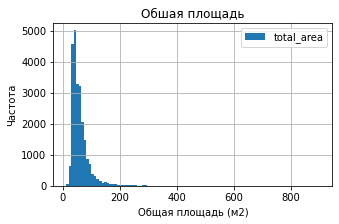

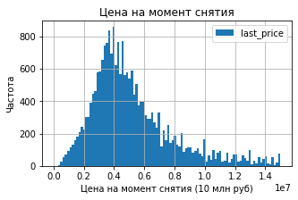

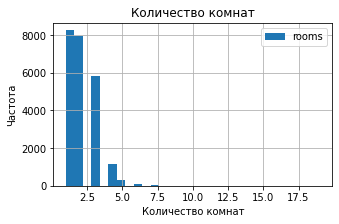

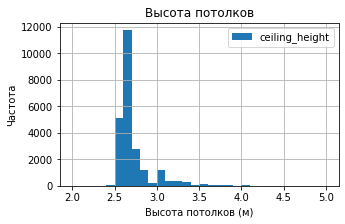

```python
# строю гистограммы
import matplotlib.pyplot as plt

df.plot(y = 'total_area',
        kind = 'hist',
        bins = 100,
        range = (12,900),
        grid=True, figsize = (5,3))
plt.xlabel('Общая площадь (м2)')
plt.ylabel('Частота')
plt.title('Обшая площадь')
plt.show()

df.plot(y = 'last_price',
        kind = 'hist',
        bins = 100,
        range = (0,15000000),
        grid=True, figsize = (5,3))
plt.xlabel('Цена на момент снятия (10 млн руб)')
plt.ylabel('Частота')
plt.title('Цена на момент снятия')
plt.show()

df.plot(y = 'rooms',
        kind = 'hist',
        bins = 30,
        grid=True, figsize = (5,3))
plt.xlabel('Количество комнат')
plt.ylabel('Частота')
plt.title('Количество комнат')
plt.show()

df.plot(y = 'ceiling_height',
            kind = 'hist',
            bins = 30,
            range = (2,5),
            grid=True, figsize = (5,3))
plt.xlabel('Высота потолков (м)')
plt.ylabel('Частота')
plt.title('Высота потолков')
plt.show()
```

**Вывод:**

Во данных есть неадекватные значения, к примеру, высоты потолков в 1 или 100 метров. О данных неадекватных значениях я бы спросил у сотрудников, предоставивших выборку данных,если бы это было возможным. Но, учитывая, что это уебный проект, то я оставлю эти выбивающиеся значения.

### Изучите время продажи квартиры. Постройте гистограмму. Посчитайте среднее и медиану. Опишите, сколько обычно занимает продажа. Когда можно считать, что продажи прошли очень быстро, а когда необычно долго?"

Истинно не известно, является ли дата снятия обьявления датой продажи квартиры. К тому же в столбце с количеством днё размещения много пропусков, поэтому не буду связывать эти параметры.

```
count   20,518.00
mean       180.89
std        219.73
min          1.00
25%         45.00
50%         95.00
75%        232.00
max      1,580.00
Name: days_exposition, dtype: float64
```

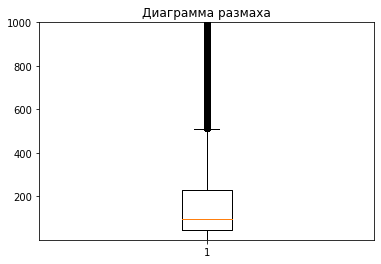

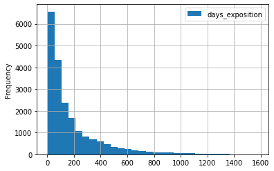

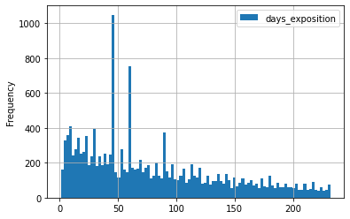

```python
# диаграмма размаха
plt.boxplot(df.loc[df['days_exposition']!=0]['days_exposition'])
plt.ylim(1,1000)
plt.title('Диаграмма размаха')

# среднее значение, медиана и межквартильный размах
print(df[~df['days_exposition'].isna()]['days_exposition'].describe())

df.plot(y = 'days_exposition', kind = 'hist', bins = 30, grid = True, range = (1,1580));
df.plot(y = 'days_exposition', kind = 'hist', bins = 100, grid = True, range = (1,232));
```

```python
# проверю аномалии со второй гистограммы
df.loc[~df['days_exposition'].isna()]['days_exposition'].value_counts().head(10)
```

```
45    880
60    538
7     234
30    208
90    204
4     176
3     158
5     152
14    148
9     143
Name: days_exposition, dtype: Int64
```

**Вывод:**

Судя по гистограмме - это распределение Пуассона. Среднее значение - 180 дней, а медиана - 95 дней. Сделав гистограмму со значениями от 0 до 232 с кол-вом корзин 100, обнаружил выбивающиеся значения и методом *value_counts()* убедился в этом. Аномалии на 45, 60, 7, 30, 90 днях - это наиболее популярное количество дней до снятия объявления.

Действительно, согласно правилам размещения объявлений в Яндекс.Недвижимость, именно по прошествии этих сроков объявление считается неактуальным и снимается автоматически.

Гиптеза подтвердилась

- факт снятия обявления напрямую не связан с продажей квартиры, но часть квартир могла и правда продаться в этот срок.

```python
# посмотрю, есть ли общее в обьявлениях снятых через 45 дней
df.loc[df['days_exposition'] == 45]
```

|  | total_images | last_price | total_area | first_day_exposition | rooms | ceiling_height | floors_total | living_area | floor | is_apartment | ... | ponds_around3000 | ponds_nearest | days_exposition | price_per_square_meter | weekday_exposition | month_exposition | year_exposition | floor_category | living_area_ratio | kitchen_area_ratio |
| --- | --- | --- | --- | --- | --- | --- | --- | --- | --- | --- | --- | --- | --- | --- | --- | --- | --- | --- | --- | --- | --- |
| 78 | 9 | 4350000 | 37.00 | 2018-02-22 | 1 | 2.65 | 19.00 | 18.00 | 6 | True | ... | 0.00 | NaN | 45 | 117567 | 3 | 2 | 2018 | другой | 0.49 | 0.29 |
| 89 | 9 | 2500000 | 63.00 | 2018-10-25 | 3 | 2.50 | 5.00 | 43.00 | 4 | True | ... | NaN | NaN | 45 | 39682 | 3 | 10 | 2018 | другой | 0.68 | 0.14 |
| 110 | 6 | 3850000 | 72.30 | 2017-09-29 | 2 | 2.65 | 3.00 | 27.40 | 2 | True | ... | NaN | NaN | 45 | 53250 | 4 | 9 | 2017 | другой | 0.38 | 0.33 |
| 153 | 12 | 4350000 | 55.00 | 2017-05-21 | 2 | 2.57 | 9.00 | 31.20 | 2 | True | ... | 0.00 | NaN | 45 | 79090 | 6 | 5 | 2017 | другой | 0.57 | 0.15 |
| 158 | 15 | 3100000 | 47.30 | 2017-11-07 | 2 | 2.65 | 5.00 | 27.50 | 2 | True | ... | NaN | NaN | 45 | 65539 | 1 | 11 | 2017 | другой | 0.58 | 0.18 |
| ... | ... | ... | ... | ... | ... | ... | ... | ... | ... | ... | ... | ... | ... | ... | ... | ... | ... | ... | ... | ... | ... |
| 23601 | 10 | 2900000 | 43.40 | 2018-01-11 | 2 | 2.65 | 5.00 | 25.04 | 1 | True | ... | 2.00 | 397.00 | 45 | 66820 | 3 | 1 | 2018 | первый | 0.58 | 0.17 |
| 23613 | 4 | 3950000 | 52.00 | 2018-03-04 | 3 | 2.65 | 5.00 | 30.00 | 2 | True | ... | 0.00 | NaN | 45 | 75961 | 6 | 3 | 2018 | другой | 0.58 | 0.17 |
| 23670 | 9 | 2450000 | 45.60 | 2018-02-08 | 1 | 2.80 | 9.00 | 26.31 | 2 | True | ... | NaN | NaN | 45 | 53728 | 3 | 2 | 2018 | другой | 0.58 | 0.17 |
| 23679 | 0 | 2500000 | 35.00 | 2017-12-08 | 1 | 2.65 | 9.00 | 20.19 | 4 | True | ... | NaN | NaN | 45 | 71428 | 4 | 12 | 2017 | другой | 0.58 | 0.17 |
| 23695 | 14 | 3100000 | 59.00 | 2018-01-15 | 3 | 2.65 | 5.00 | 38.00 | 4 | True | ... | NaN | NaN | 45 | 52542 | 0 | 1 | 2018 | другой | 0.64 | 0.14 |

880 rows × 29 columns

**Вывод:**

Никаких общих особенностей в обьявлениях, снятых через 45 дней не выявлено, потому следует убрать эти данные из расчетов. С данными 60, 90, 30 и 7 дней в столбце days_exposition, следует поступить также, так как это аномалии.

На текущий момент уже известно, что данные (45, 60, 7, 30, 90) неправильные, но они нужны, чтобы сравнить с данными, очищенными от аномалий далее.

Если бы это был не учебный проект, то было бы важным уточнить у сотрудников насчет выбивающихся значений по датам снятия объявлений, чтобы убедиться в том, какие данные необходимо исключить из выборки.

### Уберите редкие и выбивающиеся значения. Опишите, какие особенности обнаружили.

```
count   18,454.00
mean       195.80
std        226.76
min          1.00
25%         44.00
50%        114.00
75%        259.00
max      1,580.00
Name: days_exposition, dtype: float64
```

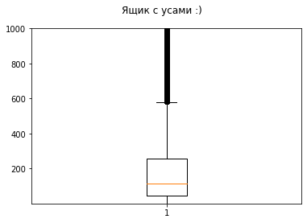

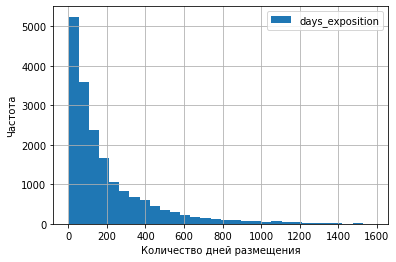

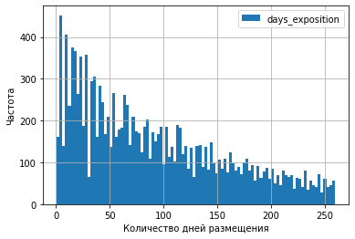

```python
# отфильтрую данные от аномалий и запишу их в новый датафрейм df_no_anomaly
df_no_anomaly = df.query('days_exposition != 45 and days_exposition != 30 and days_exposition != 60 and days_exposition != 90 and days_exposition != 7 and ~days_exposition.isna()')

#среднее значение, медиана и межквартильный размах
print(df_no_anomaly['days_exposition'].describe())

#диаграмма размаха
plt.boxplot(df_no_anomaly['days_exposition'])
plt.ylim(1,1000)
plt.suptitle('Ящик с усами :)')

#гистограммы
df_no_anomaly.plot(y = 'days_exposition', kind = 'hist', bins = 30, grid = True, range = (1,1580))
plt.xlabel('Количество дней размещения')
plt.ylabel('Частота')
df_no_anomaly.plot(y = 'days_exposition', kind = 'hist', bins = 100, grid = True, range = (1,259))
plt.xlabel('Количество дней размещения')
plt.ylabel('Частота')
```

**Вывод:**

### Какие факторы больше всего влияют на стоимость квартиры? Изучите, зависит ли цена квадратного метра от общей площади квартиры, числа комнат, этажа (первого или последнего), удалённости от центра. Также изучите зависимость от даты размещения: дня недели, месяца и года.

#### Зависимость стоимости квартиры от общей площади

```python
# делаю сводную таблицу
pivot_table_total_area = df.pivot_table(index = 'total_area',
                                        values = 'last_price',
                                        aggfunc = ['mean', 'count', 'median'])

pivot_table_total_area.columns = ['mean', 'count', 'median']
pivot_table_total_area
```

| total_area | mean | count | median |
| --- | --- | --- | --- |
| 12.00 | 2,400,000.00 | 1 | 2,400,000.00 |
| 13.00 | 2,350,000.00 | 3 | 1,850,000.00 |
| 13.20 | 1,686,000.00 | 1 | 1,686,000.00 |
| 14.00 | 1,190,000.00 | 1 | 1,190,000.00 |
| 15.00 | 1,725,000.00 | 2 | 1,725,000.00 |
| ... | ... | ... | ... |
| 590.00 | 65,000,000.00 | 1 | 65,000,000.00 |
| 618.00 | 300,000,000.00 | 1 | 300,000,000.00 |
| 631.00 | 140,000,000.00 | 1 | 140,000,000.00 |
| 631.20 | 140,000,000.00 | 1 | 140,000,000.00 |
| 900.00 | 420,000,000.00 | 1 | 420,000,000.00 |

2182 rows × 3 columns

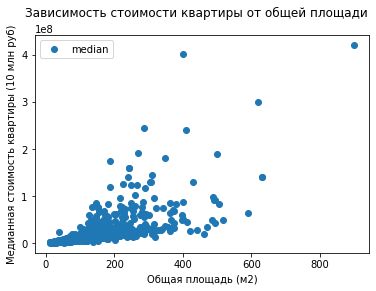

```python
# строю график
pivot_table_total_area.plot(y = 'median', style = 'o')
plt.xlabel('Общая площадь (м2)')
plt.ylabel('Медианная стоимость квартиры (10 млн руб)')
plt.suptitle('Зависимость стоимости квартиры от общей площади');
```

```python
pivot_table_total_area.sort_values('median', ascending = False)
```

| total_area | mean | count | median |
| --- | --- | --- | --- |
| 900.00 | 420,000,000.00 | 1 | 420,000,000.00 |
| 401.00 | 401,300,000.00 | 1 | 401,300,000.00 |
| 618.00 | 300,000,000.00 | 1 | 300,000,000.00 |
| 285.70 | 245,000,000.00 | 1 | 245,000,000.00 |
| 410.00 | 240,000,000.00 | 1 | 240,000,000.00 |
| ... | ... | ... | ... |
| 54.33 | 1,300,000.00 | 1 | 1,300,000.00 |
| 14.00 | 1,190,000.00 | 1 | 1,190,000.00 |
| 28.60 | 2,034,000.00 | 5 | 1,060,000.00 |
| 19.50 | 945,750.00 | 1 | 945,750.00 |
| 28.66 | 690,000.00 | 1 | 690,000.00 |

2182 rows × 3 columns

```python
# корреляция Пирсона
df['total_area'].corr(df['last_price'])
```

```
0.6537407142641289
```

**Вывод:**

Зависимость стоимости квартир от общей площади квартиры довольно большая. Согласно корреляции Пирсона равна 0,65. Это значит, что с ростом площади цена ростёт.

#### Зависимость стоимости квартир от числа комнат

```python
# делаю сводную таблицу
pivot_table_rooms = df.pivot_table(index = 'rooms',
                                   values = 'last_price',
                                   aggfunc = ['mean', 'count', 'median'])

pivot_table_rooms.columns = ['mean', 'count', 'median']
pivot_table_rooms
```

| rooms | mean | count | median |
| --- | --- | --- | --- |
| 1 | 3,823,469.90 | 8244 | 3585000 |
| 2 | 5,593,138.51 | 7940 | 4772669 |
| 3 | 8,179,118.54 | 5814 | 6200000 |
| 4 | 13,423,497.18 | 1180 | 9000000 |
| 5 | 23,762,082.09 | 326 | 14000000 |
| 6 | 31,709,751.66 | 105 | 19000000 |
| 7 | 51,470,069.08 | 59 | 24900000 |
| 8 | 50,224,166.67 | 12 | 23095000 |
| 9 | 34,152,362.50 | 8 | 23750000 |
| 10 | 26,166,666.67 | 3 | 23000000 |
| 11 | 25,250,000.00 | 2 | 25250000 |
| 12 | 420,000,000.00 | 1 | 420000000 |
| 14 | 26,829,500.00 | 2 | 26829500 |
| 15 | 65,000,000.00 | 1 | 65000000 |
| 16 | 28,500,000.00 | 1 | 28500000 |
| 19 | 32,250,000.00 | 1 | 32250000 |

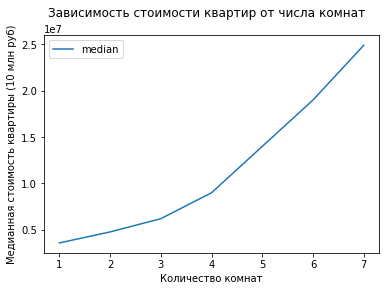

```python
# строю диаграмму по сводной таблице, где количетво значений не менее 59
pivot_table_rooms.query('count >= 59').plot(y = 'median')
plt.xlabel('Количество комнат')
plt.ylabel('Медианная стоимость квартиры (10 млн руб)')
plt.suptitle('Зависимость стоимости квартир от числа комнат');
```

```python
pivot_table_rooms.query('count >= 59').sort_values('median', ascending = False)
```

| rooms | mean | count | median |
| --- | --- | --- | --- |
| 7 | 51,470,069.08 | 59 | 24900000 |
| 6 | 31,709,751.66 | 105 | 19000000 |
| 5 | 23,762,082.09 | 326 | 14000000 |
| 4 | 13,423,497.18 | 1180 | 9000000 |
| 3 | 8,179,118.54 | 5814 | 6200000 |
| 2 | 5,593,138.51 | 7940 | 4772669 |
| 1 | 3,823,469.90 | 8244 | 3585000 |

```python
# корреляция Пирсона
df['rooms'].corr(df['last_price'])
```

```
0.3652060626788547
```

**Вывод:**

Зависимость есть. С увеличением числа комнат цена квартиры растёт. Корреляция Пирсона - 0,37.

#### Зависимость стоимости квартир от этажа (первого или последнего)

```python
# делаю сводную таблицу только для первого и последнего этажей
pivot_table_floor_category = df.query('floor_category != "другой"').pivot_table(
    index = 'floor_category',
    values = 'last_price',
    aggfunc = ['mean', 'count', 'median']
)
pivot_table_floor_category.columns = ['mean', 'count', 'median']
pivot_table_floor_category
```

| floor_category | mean | count | median |
| --- | --- | --- | --- |
| первый | 4,803,560.23 | 2917 | 3900000 |
| последний | 7,364,675.27 | 3336 | 4300000 |

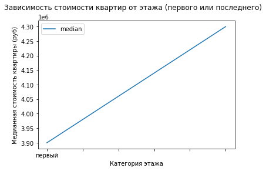

```python
# строю график
pivot_table_floor_category.plot(y = 'median')
plt.xlabel('Категория этажа')
plt.ylabel('Медианная стоимость квартиры (руб)')
plt.suptitle('Зависимость стоимости квартир от этажа (первого или последнего)');
```

**Вывод:**

#### Зависимость стоимости квартир от удалённости от центра

```
-0.21270039604789154
```

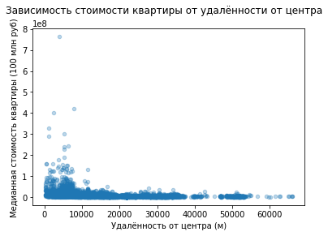

```python
# строю диаграмму рассеивания
df.plot(kind = 'scatter',
        y = 'last_price',
        x = 'cityCenters_nearest',
        alpha = 0.3)
plt.xlabel('Удалённость от центра (м)')
plt.ylabel('Медианная стоимость квартиры (100 млн руб)')
plt.suptitle('Зависимость стоимости квартиры от удалённости от центра')

# корреляция Пирсона
df['cityCenters_nearest'].corr(df['last_price'])
```

**Вывод:**

Здесь явная зависимость стоимости квартир от близости к центру, хоть и не очень сильная. Корреляция равна -0.21 Чем ближе к центру, тем выше стоимость.

```python
pivot_table_weekday_exposition = df.pivot_table(index = 'weekday_exposition',
                                                values = 'last_price',
                                                aggfunc = ['mean', 'count', 'median'])

pivot_table_weekday_exposition.columns = ['mean', 'count', 'median']
pivot_table_weekday_exposition.sort_values('median', ascending = False)
```

| weekday_exposition | mean | count | median |
| --- | --- | --- | --- |
| 1 | 6,394,233.42 | 4183 | 4730000 |
| 2 | 6,631,034.80 | 3974 | 4700000 |
| 0 | 6,511,613.42 | 3612 | 4650000 |
| 3 | 6,708,663.23 | 4295 | 4650000 |
| 4 | 6,372,130.60 | 4000 | 4585000 |
| 5 | 6,976,803.94 | 1936 | 4555000 |
| 6 | 6,246,180.30 | 1699 | 4550000 |

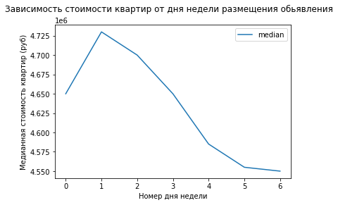

```python
pivot_table_weekday_exposition.plot(y = 'median')
plt.xlabel('Номер дня недели')
plt.ylabel('Медианная стоимость квартир (руб)')
plt.suptitle('Зависимость стоимости квартир от дня недели размещения обьявления');
```

```python
# корреляция Пирсона
df['weekday_exposition'].corr(df['last_price'])
```

```
0.0015351283292902595
```

**Вывод:**

Судя по корреляции, взаимосвязи практически нет.

Но на графике видно, что чем ближе ко вторнику выставлены объявления тем выше стоимость, но незначительно. В воскресенье стоимость самая низкая.

Возможно это связано с тем, что цену немного ниже в выходные для привлечения внимания к обьявлению, ведь в течении рабочей недели люди меньше интересуются отличными от работы вещами.

#### Зависимость стоимости квартир от месяца размещения обьявления

```python
pivot_table_month_exposition = df.pivot_table(index = 'month_exposition',
                                              values = 'last_price',
                                              aggfunc = ['mean', 'count', 'median'])

pivot_table_month_exposition.columns = ['mean', 'count', 'median']

pivot_table_month_exposition.sort_values('median', ascending = False)
```

| month_exposition | mean | count | median |
| --- | --- | --- | --- |
| 4 | 6,737,198.47 | 2379 | 4800000 |
| 9 | 6,825,470.18 | 1981 | 4700000 |
| 11 | 6,461,362.73 | 2371 | 4700000 |
| 12 | 7,011,731.43 | 1641 | 4700000 |
| 2 | 6,468,500.11 | 2640 | 4650000 |
| 3 | 6,363,982.77 | 2587 | 4650000 |
| 7 | 6,649,337.49 | 1695 | 4650000 |
| 1 | 6,668,233.13 | 1500 | 4600000 |
| 8 | 6,350,232.97 | 1744 | 4570000 |
| 10 | 6,235,013.09 | 2127 | 4570000 |
| 5 | 6,600,435.25 | 1274 | 4515000 |
| 6 | 6,310,269.40 | 1760 | 4400000 |

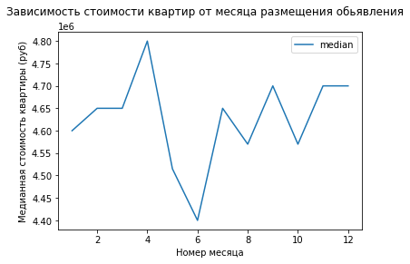

```python
pivot_table_month_exposition.plot(y = 'median')
plt.xlabel('Номер месяца')
plt.ylabel('Медианная стоимость квартиры (руб)')
plt.suptitle('Зависимость стоимости квартир от месяца размещения обьявления');
```

```python
# корреляция Пирсона
df['month_exposition'].corr(df['last_price'])
```

```
0.0027331696368698027
```

**Вывод:**

#### Зависимость стоимости квартир от года размещения обьявления

```python
pivot_table_year_exposition = df.pivot_table(index = 'year_exposition',
                                             values = 'last_price',
                                             aggfunc = ['mean', 'count', 'median'])
pivot_table_year_exposition.columns = ['mean', 'count', 'median']

pivot_table_year_exposition.sort_values('median', ascending = False)
```

| year_exposition | mean | count | median |
| --- | --- | --- | --- |
| 2014 | 12,087,135.94 | 137 | 7700000 |
| 2015 | 8,572,833.30 | 1191 | 5350000 |
| 2019 | 6,786,618.27 | 2879 | 5050000 |
| 2016 | 6,827,912.19 | 2783 | 4550000 |
| 2018 | 5,950,966.43 | 8519 | 4550000 |
| 2017 | 6,585,729.35 | 8190 | 4500000 |

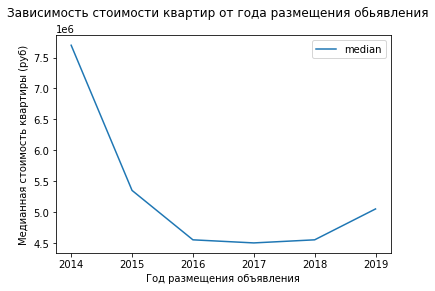

```python
pivot_table_year_exposition.plot(y = 'median')
plt.xlabel('Год размещения объявления')
plt.ylabel('Медианная стоимость квартиры (руб)')
plt.suptitle('Зависимость стоимости квартир от года размещения обьявления');
```

```python
# корреляция Пирсона
df['year_exposition'].corr(df['last_price'])
```

```
-0.04301499446349356
```

**Вывод:**

C 2014 до 2016 года цена падала, но потом начала увеличиваться!

По данным сайта rbc.ru с 2014 года происходило падение цен на невижимость из-за очередного кризиса, связанного падением цен на нефть и рубля, антироссийскими экономическими санкциями, введением контрсанкций.

По [данным PR FLAT недвижимость](https://pr-flat.ru/news/kak-vyrosli-tseny-na-nedvizhimost-v-rossii-za-poslednie-5-let/#:~:text=1-,%D0%A1%D0%B0%D0%BD%D0%BA%D1%82%2D%D0%9F%D0%B5%D1%82%D0%B5%D1%80%D0%B1%D1%83%D1%80%D0%B3,-148%20967) с 2017 года начался постепенный рост цен на недвижимость в всязи с ростом доходов населения, ростом покуптельской способностью населения и понижением ключевой ставки ЦБ РФ. За последние 5 лет в Санкт-Петербурге динамика роста цен составила 49,43%.

#### Выберите 10 населённых пунктов с наибольшим числом объявлений. Посчитайте среднюю цену квадратного метра в этих населённых пунктах. Выделите населённые пункты с самой высокой и низкой стоимостью жилья

```python
# делаю сводную таблицу по названию населенного пункта и цены квадратного метра
locality_pivot_table = df.pivot_table(index = 'locality_name',
                                        values = 'price_per_square_meter',
                                        aggfunc=['count', 'mean'])

locality_pivot_table.columns = ['count', 'mean']

# перезаписываю в переменную 10 населённых пунктов с наибольшим числом объявлений
locality_pivot_table = locality_pivot_table.sort_values('count', ascending = False).head(10)
display(locality_pivot_table)
print()
print('Самая высокая стоимость жилья')
display(locality_pivot_table[locality_pivot_table['mean']==locality_pivot_table['mean'].max()])
print()
print('Самая низкая стоимость жилья')
display(locality_pivot_table[locality_pivot_table['mean']==locality_pivot_table['mean'].min()])
```

| locality_name | count | mean |
| --- | --- | --- |
| Санкт-Петербург | 15721 | 114,855.67 |
| Мурино | 590 | 86,087.06 |
| Кудрово | 472 | 95,324.48 |
| Шушары | 440 | 78,676.90 |
| Всеволожск | 398 | 68,654.01 |
| Пушкин | 369 | 103,125.37 |
| Колпино | 338 | 75,424.15 |
| Парголово | 327 | 90,175.49 |
| Гатчина | 307 | 68,745.69 |
| Выборг | 237 | 58,141.49 |

```
Самая высокая стоимость жилья
```

| locality_name | count | mean |
| --- | --- | --- |
| Санкт-Петербург | 15721 | 114,855.67 |

```
Самая низкая стоимость жилья
```

| locality_name | count | mean |
| --- | --- | --- |
| Выборг | 237 | 58,141.49 |

**Вывод:**

Cамая высокая стоимость жилья из 10 населённых пунктов с самым большим количеством объявлений в Санкт-Петербурге, а самая низкая стоимость в Выборге.

#### Изучите предложения квартир в Санкт-Петербурге. Ваша задача — выяснить, какая область входит в центр

```python
# создаю новый столбец с расстояние до центра в км и меняю тип на 'int'
df['cityCenters_nearest_km'] = (df['cityCenters_nearest'] / 1000).apply(np.round).astype('Int64')

# проверяю
df['cityCenters_nearest_km'].sample()
```

```
9138    4
Name: cityCenters_nearest_km, dtype: Int64
```

```python
# делаю сводную таблицу по стоимости квартиры и расстоянию до центра в км
pivot_spb_cityCenters_nearest_km = df.query(
    'locality_name == "Санкт-Петербург" and ~cityCenters_nearest_km.isna()'
).pivot_table(index = 'cityCenters_nearest_km',
              values = 'last_price',
              aggfunc = 'mean')

pivot_spb_cityCenters_nearest_km
```

| cityCenters_nearest_km | last_price |
| --- | --- |
| 0 | 31,449,115.85 |
| 1 | 21,206,720.83 |
| 2 | 17,788,319.61 |
| 3 | 11,126,581.00 |
| 4 | 13,304,279.53 |
| 5 | 14,499,121.06 |
| 6 | 15,338,418.39 |
| 7 | 14,775,152.59 |
| 8 | 9,957,716.83 |
| 9 | 6,971,194.51 |
| 10 | 6,504,119.23 |
| 11 | 6,250,814.96 |
| 12 | 6,189,738.80 |
| 13 | 6,083,140.87 |
| 14 | 5,629,101.25 |
| 15 | 5,884,751.39 |
| 16 | 5,373,130.56 |
| 17 | 5,292,394.63 |
| 18 | 5,091,331.32 |
| 19 | 5,037,674.94 |
| 20 | 5,951,464.84 |
| 21 | 5,493,469.37 |
| 22 | 5,415,524.28 |
| 23 | 4,985,376.47 |
| 24 | 3,854,429.62 |
| 25 | 4,052,839.92 |
| 26 | 3,973,012.51 |
| 27 | 8,300,000.00 |
| 28 | 5,026,428.57 |
| 29 | 4,236,666.67 |

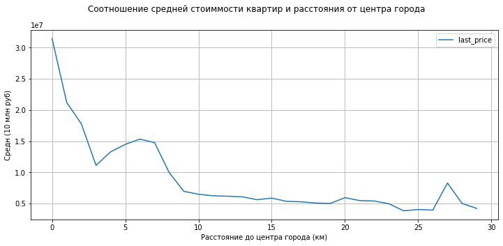

```python
pivot_spb_cityCenters_nearest_km.plot(grid=True, figsize=(12, 5))
plt.xlabel('Расстояние до центра города (км)')
plt.ylabel('Средн (10 млн руб)')
plt.suptitle('Соотношение средней стоиммости квартир и расстояния от центра города');
```

**Вывод:**

Cудя по графику центром считается радиус в 6 километров, так как дальше этого расстояния начинается спад стоимости.

Провал по стоимости в радиусе от 2.5 км до 5 км, скорее всего связан с непешей достуаностью до исторического центра, и дома, наверное, уже не такие престижные.

#### Выделите сегмент квартир в центре. Проанализируйте эту территорию и изучите следующие параметры: площадь, цена, число комнат, высота потолков. Также выделите факторы, которые влияют на стоимость квартиры (число комнат, этаж, удалённость от центра, дата размещения объявления). Сделайте выводы. Отличаются ли они от общих выводов по всему городу?

```python
# квартиры в центре c радиусом 6 км
center_spb = df.query('cityCenters_nearest_km <= 6 and locality_name == "Санкт-Петербург"')
```

```python
# зависимость стоимости квартиры от количества комнат
center_spb_rooms = center_spb.pivot_table(index = 'rooms',
                                          values = 'last_price',
                                          aggfunc = ['mean', 'count', 'median'])

center_spb_rooms.columns = ['mean', 'count', 'median']
center_spb_rooms
```

| rooms | mean | count | median |
| --- | --- | --- | --- |
| 1 | 6,880,179.44 | 460 | 6,050,000.50 |
| 2 | 10,015,481.68 | 880 | 7,950,000.00 |
| 3 | 14,564,310.22 | 952 | 10,000,000.00 |
| 4 | 17,979,631.40 | 449 | 11,990,000.00 |
| 5 | 28,248,094.61 | 211 | 14,500,000.00 |
| 6 | 35,143,746.84 | 79 | 19,500,000.00 |
| 7 | 51,994,150.94 | 53 | 24,900,000.00 |
| 8 | 49,779,000.00 | 10 | 21,045,000.00 |
| 9 | 44,666,666.67 | 3 | 29,000,000.00 |
| 10 | 27,750,000.00 | 2 | 27,750,000.00 |
| 11 | 25,250,000.00 | 2 | 25,250,000.00 |
| 14 | 28,659,000.00 | 1 | 28,659,000.00 |
| 15 | 65,000,000.00 | 1 | 65,000,000.00 |
| 16 | 28,500,000.00 | 1 | 28,500,000.00 |
| 19 | 32,250,000.00 | 1 | 32,250,000.00 |

```
0.3049021295370582
```

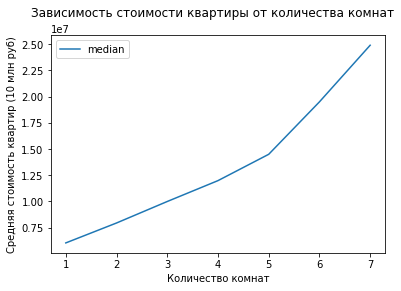

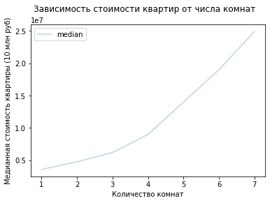

```python
# строю график
center_spb_rooms.query('count >= 18').plot(y = 'median')
plt.xlabel('Количество комнат')
plt.ylabel('Средняя стоимость квартир (10 млн руб)')
plt.suptitle('Зависимость стоимости квартиры от количества комнат')
# общая выборка
pivot_table_rooms.query('count >= 59').plot(y = 'median', alpha=0.3)
plt.xlabel('Количество комнат')
plt.ylabel('Медианная стоимость квартиры (10 млн руб)')
plt.suptitle('Зависимость стоимости квартир от числа комнат')
# корреляция Пирсона
center_spb['rooms'].corr(center_spb['last_price'])
```

```python
center_spb_rooms.query('count > 50').sort_values('median', ascending = False)
```

| rooms | mean | count | median |
| --- | --- | --- | --- |
| 7 | 51,994,150.94 | 53 | 24,900,000.00 |
| 6 | 35,143,746.84 | 79 | 19,500,000.00 |
| 5 | 28,248,094.61 | 211 | 14,500,000.00 |
| 4 | 17,979,631.40 | 449 | 11,990,000.00 |
| 3 | 14,564,310.22 | 952 | 10,000,000.00 |
| 2 | 10,015,481.68 | 880 | 7,950,000.00 |
| 1 | 6,880,179.44 | 460 | 6,050,000.50 |

**Вывод:**

По графику и медианной стоимости видно, что в центре Санкт-Петербурга с увеличением числа комнат, растёт и цена квартиры. Это не отличается от всей выборки. Коэфициент корреляции по центру 0.3 тоже не сильно отличается от коэфициента 0.36 для всей выборки.

```python
# зависимость стоимости квартиры от этажа
center_spb_floor = center_spb.query('floor_category != "другой"').pivot_table(
    index = 'floor_category',
    values = 'last_price',
    aggfunc = ['mean', 'count', 'median'])
center_spb_floor.columns = ['mean', 'count', 'median']
center_spb_floor
```

| floor_category | mean | count | median |
| --- | --- | --- | --- |
| первый | 9,363,417.77 | 353 | 6800000 |
| последний | 18,689,125.96 | 567 | 9500000 |

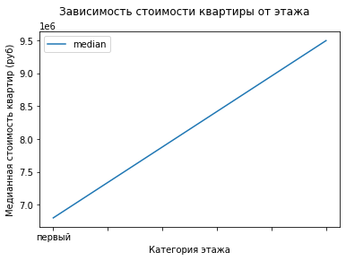

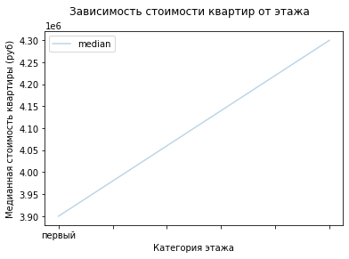

```python
center_spb_floor.plot(y = 'median')
plt.xlabel('Категория этажа')
plt.ylabel('Медианная стоимость квартир (руб)')
plt.suptitle('Зависимость стоимости квартиры от этажа')

# общая выборка
pivot_table_floor_category.plot(y = 'median', alpha=0.3)
plt.xlabel('Категория этажа')
plt.ylabel('Медианная стоимость квартиры (руб)')
plt.suptitle('Зависимость стоимости квартир от этажа')
plt.show()
```

**Вывод:** Отличий от всей выборки квартир нет. Квартиры на первом этаже дешевле, чем на последнем.

```
-0.05043937954089685
```

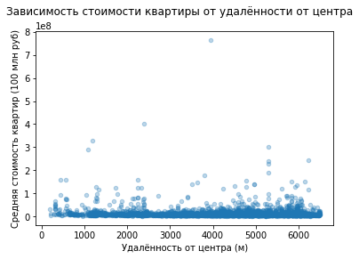

```python
# зависимость стоимости квартиры от удалённости от центра
center_spb.plot(kind = 'scatter',
                y = 'last_price',
                x = 'cityCenters_nearest',
                alpha = 0.3)
plt.xlabel('Удалённость от центра (м)')
plt.ylabel('Средняя стоимость квартир (100 млн руб)')
plt.suptitle('Зависимость стоимости квартиры от удалённости от центра')

center_spb['cityCenters_nearest'].corr(center_spb['last_price'])
```

**Вывод:**

Как и следовало ожидать явной взаимосвязи нет, так как иследуется выборка по центру города.

```python
# зависимость стоимости квартиры от дня недели размещения объявления
center_spb_weekday = center_spb.pivot_table(index = 'weekday_exposition',
                                            values = 'last_price',
                                            aggfunc = ['mean', 'count', 'median'])
center_spb_weekday.columns = ['mean', 'count', 'median']

center_spb_weekday.sort_values('median', ascending = False)
```

| weekday_exposition | mean | count | median |
| --- | --- | --- | --- |
| 0 | 14,600,557.02 | 479 | 9500000 |
| 2 | 14,581,574.38 | 543 | 9500000 |
| 6 | 15,335,417.21 | 165 | 9500000 |
| 3 | 14,649,899.64 | 638 | 9490200 |
| 1 | 14,130,885.25 | 530 | 9400000 |
| 4 | 14,516,239.65 | 528 | 9000000 |
| 5 | 19,634,198.14 | 222 | 8860000 |

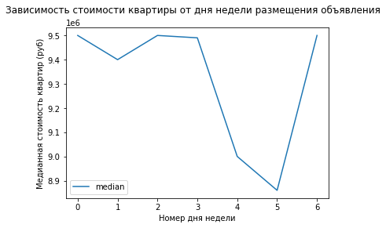

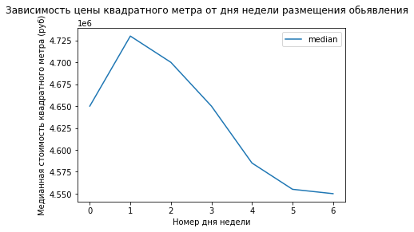

```python
center_spb_weekday.plot(y = 'median')
plt.xlabel('Номер дня недели')
plt.ylabel('Медианная стоимость квартир (руб)')
plt.suptitle('Зависимость стоимости квартиры от дня недели размещения объявления')
# общая выборка
pivot_table_weekday_exposition.plot(y = 'median')
plt.xlabel('Номер дня недели')
plt.ylabel('Медианная стоимость квадратного метра (руб)')
plt.suptitle('Зависимость цены квадратного метра от дня недели размещения обьявления')
plt.show()
```

**Вывод:**

Cитуация немного отличается от всей выборки: минимальные медианная цена в пятницу и субботу, самые высокие - в понедельник, среду, четверг и воскресенье. Связано это, скорее всего, с тем, что спрос на квартиры в центре выше.

```python
# зависимость стоимости квартиры от месяца размещения объявления
center_spb_month = center_spb.pivot_table(index = 'month_exposition',
                                          values = 'last_price',
                                          aggfunc = ['mean', 'count', 'median'])
center_spb_month.columns = ['mean', 'count', 'median']

center_spb_month.sort_values('median', ascending = False)
```

| month_exposition | mean | count | median |
| --- | --- | --- | --- |
| 1 | 16,271,914.55 | 190 | 10625000 |
| 9 | 16,128,873.37 | 272 | 9995000 |
| 2 | 15,286,735.13 | 345 | 9600000 |
| 3 | 15,158,705.00 | 333 | 9500000 |
| 11 | 14,293,834.07 | 308 | 9500000 |
| 4 | 16,437,574.24 | 287 | 9410000 |
| 7 | 14,688,367.60 | 252 | 9250000 |
| 8 | 13,957,137.87 | 228 | 9100000 |
| 5 | 13,841,816.75 | 170 | 8990000 |
| 12 | 16,167,732.55 | 214 | 8960500 |
| 10 | 13,814,259.67 | 253 | 8755014 |
| 6 | 12,604,329.75 | 253 | 8600000 |

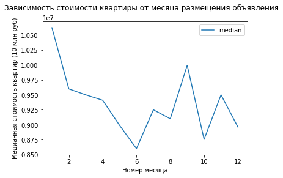

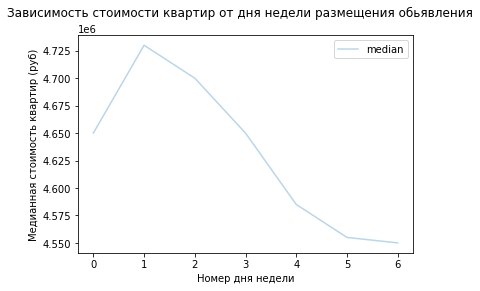

```python
center_spb_month.plot(y = 'median')
plt.xlabel('Номер месяца')
plt.ylabel('Медианная стоимость квартир (10 млн руб)')
plt.suptitle('Зависимость стоимости квартиры от месяца размещения объявления')
# общая выборка
pivot_table_weekday_exposition.plot(y = 'median', alpha=0.3)
plt.xlabel('Номер дня недели')
plt.ylabel('Медианная стоимость квартир (руб)')
plt.suptitle('Зависимость стоимости квартир от дня недели размещения обьявления')
plt.show()
```

**Вывод:**

Как видно по графику, ситуация отличается от общей выборкой - самая высокая стоимость квартиры - в январе и сентябре. Самая низкая стоимость - в июне и октябре.

Самый пик цены связан с началом года и новогодними праздниками, а также с началом учебного года. В то время как самая низкая цена в июне, скорее всего связанв с сезоном отпусков. Видимо, сезонность так же влияет на стоимость квартир в центре, хоть и чуть меньше, чем на всю выбоку.

```python
# зависимость стоимости квартиры от года размещения объявления
center_spb_year = center_spb.pivot_table(index = 'year_exposition',
                                         values = 'last_price',
                                         aggfunc = ['mean', 'count', 'median'])
center_spb_year.columns = ['mean', 'count', 'median']
center_spb_year.sort_values('median', ascending = False)
```

| year_exposition | mean | count | median |
| --- | --- | --- | --- |
| 2014 | 24,175,332.00 | 26 | 19445000 |
| 2015 | 17,006,325.90 | 280 | 10500000 |
| 2019 | 15,872,562.83 | 327 | 10000000 |
| 2016 | 14,524,206.00 | 434 | 9325000 |
| 2017 | 15,602,378.49 | 1107 | 9200000 |
| 2018 | 13,045,307.08 | 931 | 9000000 |

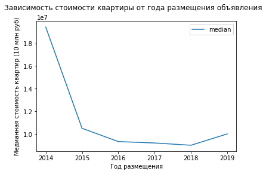

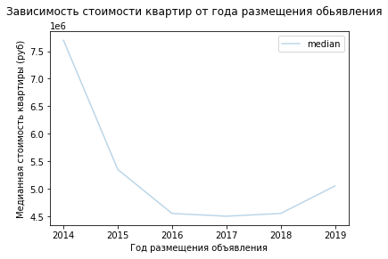

```python
center_spb_year.plot(y = 'median')
plt.xlabel('Год размещения')
plt.ylabel('Медианная стоимость квартир (10 млн руб)')
plt.suptitle('Зависимость стоимости квартиры от года размещения объявления')
# общая выборка
pivot_table_year_exposition.plot(y = 'median', alpha=0.3)
plt.xlabel('Год размещения объявления')
plt.ylabel('Медианная стоимость квартиры (руб)')
plt.suptitle('Зависимость стоимости квартир от года размещения обьявления');
```

**Вывод:**

Судя по графику, цены на квартиры в центре падали с 2014 по 2016 также как и в общей выборке, но с одним отличием. С 2016 не наступил рост цен, а, наоборот, продолжилось падение цен до 2018г. А после начался незначительный рост цен. Скорее всего, это связано с тем, что после 2016г началась активная постройка новых домов и домов премиум класса в удалении от центра и пробок, и люди активно хотели покупать эту недвижимость.

## Общий вывод

Изучая время продажи квартир заметил, что большое количество объявлений было автоматически снято с Яндекс.Недвижимость, и дату из снятия нельзя считать датой продажи квартиры. Поэтому, изучая средние сроки продажи квартир, эти значения не учитывались.

Важно учесть, что, рассматривая среднюю стоимость квартир в 2014-2019 годах, я не делал сегментацию рынка, а лишь смотрел средние показатели по рынку в целом. Возможно, что цены на аналогичные квартиры в разные годы вели себя абсолютно по-разному. Именно об этом и говорят данные, полученные при изучении единственного сегмента квартир - находящихся в радиусе 6 км в центре.